# Adult WEBL provisioning behavior in heat

```r
gtsave(tab,"../figures/int_tab_provis_ch3_q4h3_webl_2.html")

summary(m_WEBL_alldoubles)
```

```
##  Family: nbinom2  ( log )
## Formula:
## valid_detections ~ poly(mean_temp_scaled, 2) * deghours_diff_35C_priorday_scaled +
##     poly(mean_temp_scaled, 2) * cort_s1_mother_scaled + deghours_diff_35C_priorday_scaled *
##     cort_s1_mother_scaled + mean_nestling_age_scaled + brood_size_scaled +
##     year_fct + (1 | site:attempt_id)
## Zero inflation:                    ~1
## Data: dplyr::filter(p, !is.na(mean_temp), !is.na(mean_nestling_age),
##     !is.na(deghours_diff_35C_priorday), !is.na(cort_s1_mother),
##     !is.na(brood_size), !is.na(tod_h), !is.na(site), !is.na(attempt_id),
##     !is.na(year_fct), species == "WEBL") %>% mutate(across(c(tod_h,
##     mean_temp, deghours_diff_35C_priorday, cort_s1_mother, julian_date,
##     mean_nestling_age, brood_size), ~scale(.x)[, 1], .names = "{.col}_scaled"))
##
##      AIC      BIC   logLik deviance df.resid
##    794.6    842.0   -381.3    762.6      127
##
## Random effects:
##
## Conditional model:
##  Groups          Name        Variance Std.Dev.
##  site:attempt_id (Intercept) 0.3799   0.6164
## Number of obs: 143, groups:  site:attempt_id, 12
##
## Dispersion parameter for nbinom2 family (): 9.41
##
## Conditional model:
##                                                              Estimate
## (Intercept)                                                   1.74360
## poly(mean_temp_scaled, 2)1                                   -4.39761
## poly(mean_temp_scaled, 2)2                                   -4.24396
## deghours_diff_35C_priorday_scaled                             0.04563
## cort_s1_mother_scaled                                        -0.47319
## mean_nestling_age_scaled                                      0.33170
## brood_size_scaled                                             0.70178
## year_fct2023                                                 -0.86937
## poly(mean_temp_scaled, 2)1:deghours_diff_35C_priorday_scaled -3.59997
## poly(mean_temp_scaled, 2)2:deghours_diff_35C_priorday_scaled -3.33692
## poly(mean_temp_scaled, 2)1:cort_s1_mother_scaled             -1.01189
## poly(mean_temp_scaled, 2)2:cort_s1_mother_scaled              3.78596
```

[output cut: 22 more lines]

```
## brood_size_scaled                                            0.002825 **
## year_fct2023                                                 0.099551 .
## poly(mean_temp_scaled, 2)1:deghours_diff_35C_priorday_scaled 0.013328 *
## poly(mean_temp_scaled, 2)2:deghours_diff_35C_priorday_scaled 0.005991 **
## poly(mean_temp_scaled, 2)1:cort_s1_mother_scaled             0.516607
## poly(mean_temp_scaled, 2)2:cort_s1_mother_scaled             0.000429 ***
## deghours_diff_35C_priorday_scaled:cort_s1_mother_scaled      0.001645 **
## ---
## Signif. codes:  0 '***' 0.001 '**' 0.01 '*' 0.05 '.' 0.1 ' ' 1
##
## Zero-inflation model:
##             Estimate Std. Error z value Pr(>|z|)
## (Intercept)   -4.188      1.056  -3.965 7.35e-05 ***
## ---
## Signif. codes:  0 '***' 0.001 '**' 0.01 '*' 0.05 '.' 0.1 ' ' 1
```

```r
m_webl_q4h3 <- m_WEBL_alldoubles

check_zeroinflation(m_WEBL_alldoubles)
```

```
## # Check for zero-inflation
##
##    Observed zeros: 16
##   Predicted zeros: 14
##             Ratio: 0.85
```

```
## Model is underfitting zeros (probable zero-inflation) (p = 0.640).
```

```r
# (t <- emtrends(m_webl_q1h1,specs = ~ habitat, var = c("mean_temp_scaled"),max.degree = 1) %>% test() %>%
#    mutate(across(where(is.numeric), ~ round(.x, digits = 3)),
#           df = round(df),
#           p.value = if_else(p.value == 0.000,"<0.001",as.character(p.value))) %>%
#    rename(Habitat = "habitat", `Max temp trend` = "mean_temp_scaled.trend",Df = "df", `Z-ratio` = "z.ratio", P = "p.value") %>%
#    #group_by(degree) %>%
#    gt())

ss_year_webl_provis_q4h3 <- m_webl_q4h3$frame %>%
  group_by(year_fct) %>%
  summarize(count_ind = n(),count_attempt = n_distinct(attempt_id)) %>%
  rowwise() %>%
  mutate(count = tibble(count_ind,count_attempt)) %>%
  dplyr::select(-c(count_ind, count_attempt)) %>%
  pivot_wider(values_from = count,names_from = year_fct) %>%
  as.tibble() %>% # rename(Habitat = 'habitat') %>%
  ungroup() %>%
  # mutate(`2021` = replace_na(`2021`,list(count_ind = 0,count_attempt = 0))) %>%
  mutate(Total = `2022` + `2023`) %>%
  rowwise() %>%
  mutate(`2022` = paste0(`2022`$count_ind,", ",`2022`$count_attempt),
         `2023` = paste0(`2023`$count_ind,", ",`2023`$count_attempt),
         Total = paste0(Total$count_ind,", ",Total$count_attempt)
  )

(t_ss_year_webl_provis_q4h3 <- ss_year_webl_provis_q4h3 %>% gt() %>%
    grand_summary_rows(fns = list(id = "Total") ~ {
      t <- str_split(.,", ",simplify = TRUE)
      t[,1] %>% as.numeric() %>% sum(na.rm = TRUE) %>% paste(t[,2] %>% as.numeric() %>% sum(na.rm = TRUE),sep = ", ")
    })
)
```

|  | 2022 | 2023 | Total |
| --- | --- | --- | --- |
|  | 88, 5 | 55, 7 | 143, 12 |
| Total | 88, 5 | 55, 7 | 143, 12 |

```r
t_ss_year_webl_provis_q4h3 %>% gtsave("../figures/ss_year_webl_provis_ch3_q4h3.html")

samp_q4h3 <- m_webl_q4h3$frame %>% summarize(count = n())
samp_q4h3 %>% gt() %>% gtsave("../figures/ss_webl_provis_ch3_q4h3.html")


dat_text_webl_q4h3 <- data.frame(
  label = paste("N =",samp_q4h3$count)# ,
  #group   = factor(c("Forest","Orchard","Grassland","Row crop"))
)

## num nestboxes
m_webl_q4h3$frame %>% pull(attempt_id) %>% unique() %>% length()
```

```
## [1] 12
```

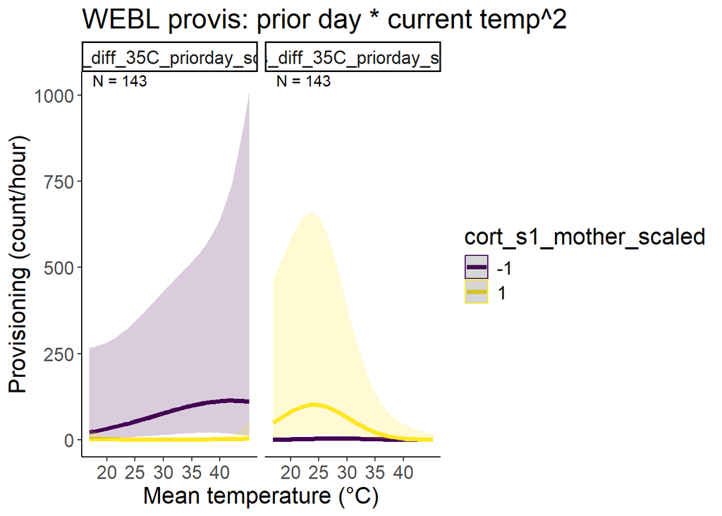

```r
data_webl_q4h3 = dplyr::filter(p,!is.na(mean_temp),
                                  # !is.na(julian_date),
                                  !is.na(mean_nestling_age),
                                  !is.na(deghours_diff_35C_priorday),
                                  !is.na(cort_s1_mother),
                                  !is.na(brood_size),
                                  !is.na(tod_h),
                                  !is.na(site),
                                  !is.na(attempt_id),
                                  !is.na(year_fct),
                                  species == "WEBL"# ,
                                                # tod >= hms::as.hms('11:00:00', tz = "America/Los_Angeles"),
                                                # tod_end <= hms::as.hms('17:00:00',tz = "America/Los_Angeles"),
                                                # tod_end >= hms::as.hms('11:00:00', tz = "America/Los_Angeles")
                                                ) %>%
                        mutate(across(c(tod_h,mean_temp,deghours_diff_35C_priorday,cort_s1_mother,julian_date,mean_nestling_age,brood_size),
                                                    ~ scale(.x)[,1],
                                                    .names = "{.col}_scaled"))


mean_temp_webl_q4h3 <- mean(data_webl_q4h3 %>% pull(mean_temp))
sd_temp_webl_q4h3 <- sd(data_webl_q4h3 %>% pull(mean_temp))


temp_trans_webl_q4h3 <- trans_new("temp_trans_webl_q4h3",
                             transform = function(x){(x * sd_temp_webl_q4h3) + mean_temp_webl_q4h3},
                             inverse = function(x){x})

(figq4h3_webl <- predict_response(m_webl_q4h3,terms = c("mean_temp_scaled [all]","cort_s1_mother_scaled [-1,1]","deghours_diff_35C_priorday_scaled [-2,2]")) %>%
    plot(line_size = 1.5,alpha = .2,limit_range = TRUE,colors = "viridis") +
    # scale_color_hue(labels = c("Low","High")) +
    # aes(linetype = .data[["group"]]) +
    theme_classic() +
    # facet_wrap(~ group, ncol = 2) +
    xlab("Mean temperature (\u00b0C)") +
    ylab("Provisioning (count/hour)") +
    # scale_fill_viridis(discrete = TRUE) +
    # scale_color_viridis(discrete = TRUE) +
    theme(text = element_text(size = 16)) +
    labs(title =  "WEBL provis: prior day * current temp^2") +
    scale_x_continuous(trans = temp_trans_webl_q4h3,
                       breaks = c((20-mean_temp_webl_q4h3)/sd_temp_webl_q4h3,
                                  (25-mean_temp_webl_q4h3)/sd_temp_webl_q4h3,
                                  (30-mean_temp_webl_q4h3)/sd_temp_webl_q4h3,
                                  (35-mean_temp_webl_q4h3)/sd_temp_webl_q4h3,
                                  (40-mean_temp_webl_q4h3)/sd_temp_webl_q4h3),
                       # breaks = c(20,30,40,50),
                       # labels = c("20","30","40","50"),
                       # limits = c((15-mean(g$meanmaxtempI,na.rm = TRUE))/sd(g$meanmaxtempI,na.rm = TRUE),
                       #            (55-mean(g$meanmaxtempI,na.rm = TRUE))/sd(g$meanmaxtempI,na.rm = TRUE))
                       # limits = c(18,5)
    ) +
    # scale_linetype_manual(values = "solid") +
    # ylim(0,200) +
    geom_text(data = dat_text_webl_q4h3, mapping = aes(x = -Inf, y = Inf,label = label),hjust = -.2, vjust = 1.2,inherit.aes = FALSE) # +
    #theme(legend.position = "none")
)
```

```r
ggsave("../figures/provisbymaxtempxhab_WEBL_q4h3.png",plot =  figq4h3_webl, width = 10, height = 6.6)
```

### TRES

```r
m_TRES <- glmmTMB(valid_detections ~ poly(mean_temp_scaled,2) * deghours_diff_35C_priorday_scaled * cort_s1_mother_scaled + mean_nestling_age_scaled + brood_size_scaled + year_fct +  (1|site:attempt_id),
           family = nbinom2(),
           ziformula = ~ 1,
           data = dplyr::filter(p,!is.na(mean_temp),
                                  # !is.na(julian_date),
                                  !is.na(mean_nestling_age),
                                  !is.na(deghours_diff_35C_priorday),
                                  !is.na(cort_s1_mother),
                                  !is.na(brood_size),
                                  !is.na(tod_h),
                                  !is.na(site),
                                  !is.na(attempt_id),
                                  !is.na(year_fct),
                                  species == "TRES"# ,
                                                # tod >= hms::as.hms('11:00:00', tz = "America/Los_Angeles"),
                                                # tod_end <= hms::as.hms('17:00:00',tz = "America/Los_Angeles"),
                                                # tod_end >= hms::as.hms('11:00:00', tz = "America/Los_Angeles")
                                                ) %>%
                        mutate(across(c(tod_h,mean_temp,deghours_diff_35C_priorday,cort_s1_mother,julian_date,mean_nestling_age,brood_size),
                                                    ~ scale(.x)[,1],
                                                    .names = "{.col}_scaled")),
           )

m_TRES_alldoubles <- glmmTMB(valid_detections ~ poly(mean_temp_scaled,2) * deghours_diff_35C_priorday_scaled + poly(mean_temp_scaled,2) * cort_s1_mother_scaled + deghours_diff_35C_priorday_scaled * cort_s1_mother_scaled + mean_nestling_age_scaled + brood_size_scaled + year_fct +  (1|site:attempt_id),
           family = nbinom2(),
           ziformula = ~ 1,
           data = dplyr::filter(p,!is.na(mean_temp),
                                  # !is.na(julian_date),
                                  !is.na(mean_nestling_age),
                                  !is.na(deghours_diff_35C_priorday),
                                  !is.na(cort_s1_mother),
                                  !is.na(brood_size),
                                  !is.na(tod_h),
                                  !is.na(site),
                                  !is.na(attempt_id),
                                  !is.na(year_fct),
                                  species == "TRES"# ,
                                                # tod >= hms::as.hms('11:00:00', tz = "America/Los_Angeles"),
                                                # tod_end <= hms::as.hms('17:00:00',tz = "America/Los_Angeles"),
                                                # tod_end >= hms::as.hms('11:00:00', tz = "America/Los_Angeles")
                                                ) %>%
                        mutate(across(c(tod_h,mean_temp,deghours_diff_35C_priorday,cort_s1_mother,julian_date,mean_nestling_age,brood_size),
                                                    ~ scale(.x)[,1],
                                                    .names = "{.col}_scaled")),
           )

m_TRES_deghxfc <- glmmTMB(valid_detections ~ poly(mean_temp_scaled,2) + deghours_diff_35C_priorday_scaled * cort_s1_mother_scaled + mean_nestling_age_scaled + brood_size_scaled + year_fct +  (1|site:attempt_id),
           family = nbinom2(),
           ziformula = ~ 1,
           data = dplyr::filter(p,!is.na(mean_temp),
                                  # !is.na(julian_date),
                                  !is.na(mean_nestling_age),
                                  !is.na(deghours_diff_35C_priorday),
                                  !is.na(cort_s1_mother),
                                  !is.na(brood_size),
                                  !is.na(tod_h),
                                  !is.na(site),
                                  !is.na(attempt_id),
                                  !is.na(year_fct),
                                  species == "TRES"# ,
                                                # tod >= hms::as.hms('11:00:00', tz = "America/Los_Angeles"),
                                                # tod_end <= hms::as.hms('17:00:00',tz = "America/Los_Angeles"),
                                                # tod_end >= hms::as.hms('11:00:00', tz = "America/Los_Angeles")
                                                ) %>%
                        mutate(across(c(tod_h,mean_temp,deghours_diff_35C_priorday,cort_s1_mother,julian_date,mean_nestling_age,brood_size),
                                                    ~ scale(.x)[,1],
                                                    .names = "{.col}_scaled")),
           )

m_TRES_mtxdegh <- glmmTMB(valid_detections ~ poly(mean_temp_scaled,2) * deghours_diff_35C_priorday_scaled + cort_s1_mother_scaled + mean_nestling_age_scaled + brood_size_scaled + year_fct +  (1|site:attempt_id),
           family = nbinom2(),
           ziformula = ~ 1,
           data = dplyr::filter(p,!is.na(mean_temp),
                                  # !is.na(julian_date),
                                  !is.na(mean_nestling_age),
                                  !is.na(deghours_diff_35C_priorday),
                                  !is.na(cort_s1_mother),
                                  !is.na(brood_size),
                                  !is.na(tod_h),
                                  !is.na(site),
                                  !is.na(attempt_id),
                                  !is.na(year_fct),
                                  species == "TRES"# ,
                                                # tod >= hms::as.hms('11:00:00', tz = "America/Los_Angeles"),
                                                # tod_end <= hms::as.hms('17:00:00',tz = "America/Los_Angeles"),
                                                # tod_end >= hms::as.hms('11:00:00', tz = "America/Los_Angeles")
                                                ) %>%
                        mutate(across(c(tod_h,mean_temp,deghours_diff_35C_priorday,cort_s1_mother,julian_date,mean_nestling_age,brood_size),
                                                    ~ scale(.x)[,1],
                                                    .names = "{.col}_scaled")),
           )

m_TRES_mtxfc <- glmmTMB(valid_detections ~ poly(mean_temp_scaled,2) * cort_s1_mother_scaled + deghours_diff_35C_priorday_scaled + mean_nestling_age_scaled + brood_size_scaled + year_fct +  (1|site:attempt_id),
           family = nbinom2(),
           ziformula = ~ 1,
           data = dplyr::filter(p,!is.na(mean_temp),
                                  # !is.na(julian_date),
                                  !is.na(mean_nestling_age),
                                  !is.na(deghours_diff_35C_priorday),
                                  !is.na(cort_s1_mother),
                                  !is.na(brood_size),
                                  !is.na(tod_h),
                                  !is.na(site),
                                  !is.na(attempt_id),
                                  !is.na(year_fct),
                                  species == "TRES"# ,
                                                # tod >= hms::as.hms('11:00:00', tz = "America/Los_Angeles"),
                                                # tod_end <= hms::as.hms('17:00:00',tz = "America/Los_Angeles"),
                                                # tod_end >= hms::as.hms('11:00:00', tz = "America/Los_Angeles")
                                                ) %>%
                        mutate(across(c(tod_h,mean_temp,deghours_diff_35C_priorday,cort_s1_mother,julian_date,mean_nestling_age,brood_size),
                                                    ~ scale(.x)[,1],
                                                    .names = "{.col}_scaled")),
           )

m_TRES_noint <- glmmTMB(valid_detections ~ poly(mean_temp_scaled,2) + deghours_diff_35C_priorday_scaled + cort_s1_mother_scaled + mean_nestling_age_scaled + brood_size_scaled + year_fct +  (1|site:attempt_id),
           family = nbinom2(),
           ziformula = ~ 1,
           data = dplyr::filter(p,!is.na(mean_temp),
                                  # !is.na(julian_date),
                                  !is.na(mean_nestling_age),
                                  !is.na(deghours_diff_35C_priorday),
                                  !is.na(cort_s1_mother),
                                  !is.na(brood_size),
                                  !is.na(tod_h),
                                  !is.na(site),
                                  !is.na(attempt_id),
                                  !is.na(year_fct),
                                  species == "TRES"# ,
                                                # tod >= hms::as.hms('11:00:00', tz = "America/Los_Angeles"),
                                                # tod_end <= hms::as.hms('17:00:00',tz = "America/Los_Angeles"),
                                                # tod_end >= hms::as.hms('11:00:00', tz = "America/Los_Angeles")
                                                ) %>%
                        mutate(across(c(tod_h,mean_temp,deghours_diff_35C_priorday,cort_s1_mother,julian_date,mean_nestling_age,brood_size),
                                                    ~ scale(.x)[,1],
                                                    .names = "{.col}_scaled")),
           )

c <- anova(m_TRES,m_TRES_alldoubles,m_TRES_mtxdegh,m_TRES_deghxfc,m_TRES_mtxfc) %>% tibble() %>% mutate(Model = c("Degree-hour * female condition","Mean temp * Degree-hour","Mean temp * female condition","All double interactions","Triple interaction"),.before = Df)

(tab <- c %>%
  as.tibble() %>%
  mutate(across(where(is.numeric),~round(.x,digits = 4)),
         P = `Pr(>Chisq)`) %>%
  dplyr::select(Model,AIC,Chisq,P) %>%
  mutate(across(c(AIC,Chisq), ~ round(.x, digits = 2)),
         P = if_else(P < 0.001,"<0.001",as.character(P))) %>% gt())
```

| Model | AIC | Chisq | P |
| --- | --- | --- | --- |
| Degree-hour * female condition | 988.16 | NA | NA |
| Mean temp * Degree-hour | 971.27 | 18.89 | <0.001 |
| Mean temp * female condition | 987.70 | 0.00 | 1 |
| All double interactions | 976.79 | 16.91 | <0.001 |
| Triple interaction | 980.68 | 0.11 | 0.9463 |

```r
gtsave(tab,"../figures/int_tab_provis_ch3_q4h3_tres_1.html")

c <- anova(m_TRES_alldoubles,m_TRES_mtxdegh) %>% tibble() %>% mutate(Model = c("Mean temp * Degree-hour","Triple interaction"),.before = Df)

(tab <- c %>%
  as.tibble() %>%
  mutate(across(where(is.numeric),~round(.x,digits = 4)),
         P = `Pr(>Chisq)`) %>%
  dplyr::select(Model,AIC,Chisq,P) %>%
  mutate(across(c(AIC,Chisq), ~ round(.x, digits = 2)),
         P = if_else(P < 0.001,"<0.001",as.character(P))) %>% gt())
```

| Model | AIC | Chisq | P |
| --- | --- | --- | --- |
| Mean temp * Degree-hour | 971.27 | NA | NA |
| Triple interaction | 976.79 | 0.48 | 0.9239 |

```r
gtsave(tab,"../figures/int_tab_provis_ch3_q4h3_tres_2.html")

summary(m_TRES_mtxdegh)
```

```
##  Family: nbinom2  ( log )
## Formula:
## valid_detections ~ poly(mean_temp_scaled, 2) * deghours_diff_35C_priorday_scaled +
##     cort_s1_mother_scaled + mean_nestling_age_scaled + brood_size_scaled +
##     year_fct + (1 | site:attempt_id)
## Zero inflation:                    ~1
## Data: dplyr::filter(p, !is.na(mean_temp), !is.na(mean_nestling_age),
##     !is.na(deghours_diff_35C_priorday), !is.na(cort_s1_mother),
##     !is.na(brood_size), !is.na(tod_h), !is.na(site), !is.na(attempt_id),
##     !is.na(year_fct), species == "TRES") %>% mutate(across(c(tod_h,
##     mean_temp, deghours_diff_35C_priorday, cort_s1_mother, julian_date,
##     mean_nestling_age, brood_size), ~scale(.x)[, 1], .names = "{.col}_scaled"))
##
##      AIC      BIC   logLik deviance df.resid
##    971.3   1010.1   -472.6    945.3      134
##
## Random effects:
##
## Conditional model:
##  Groups          Name        Variance Std.Dev.
##  site:attempt_id (Intercept) 1.241    1.114
## Number of obs: 147, groups:  site:attempt_id, 13
##
## Dispersion parameter for nbinom2 family (): 3.66
##
## Conditional model:
##                                                              Estimate
## (Intercept)                                                   2.28254
## poly(mean_temp_scaled, 2)1                                    3.86973
## poly(mean_temp_scaled, 2)2                                    0.14035
## deghours_diff_35C_priorday_scaled                            -0.32939
## cort_s1_mother_scaled                                        -0.71285
## mean_nestling_age_scaled                                     -0.04805
## brood_size_scaled                                             0.56680
## year_fct2023                                                 -0.34092
## poly(mean_temp_scaled, 2)1:deghours_diff_35C_priorday_scaled  1.25518
## poly(mean_temp_scaled, 2)2:deghours_diff_35C_priorday_scaled  4.56706
##                                                              Std. Error z value
## (Intercept)                                                     0.50410   4.528
## poly(mean_temp_scaled, 2)1                                      1.21700   3.180
```

[output cut: 12 more lines]

```
## deghours_diff_35C_priorday_scaled                             0.03300 *
## cort_s1_mother_scaled                                         0.06011 .
## mean_nestling_age_scaled                                      0.60596
## brood_size_scaled                                             0.18603
## year_fct2023                                                  0.64230
## poly(mean_temp_scaled, 2)1:deghours_diff_35C_priorday_scaled  0.25963
## poly(mean_temp_scaled, 2)2:deghours_diff_35C_priorday_scaled 9.76e-06 ***
## ---
## Signif. codes:  0 '***' 0.001 '**' 0.01 '*' 0.05 '.' 0.1 ' ' 1
##
## Zero-inflation model:
##             Estimate Std. Error z value Pr(>|z|)
## (Intercept)  -2.0423     0.3028  -6.744 1.54e-11 ***
## ---
## Signif. codes:  0 '***' 0.001 '**' 0.01 '*' 0.05 '.' 0.1 ' ' 1
```

```r
m_tres_q4h3 <- m_TRES_mtxdegh

check_zeroinflation(m_TRES_mtxdegh)
```

```
## # Check for zero-inflation
##
##    Observed zeros: 29
##   Predicted zeros: 32
##             Ratio: 1.09
```

```
## Model seems ok, ratio of observed and predicted zeros is within the
##   tolerance range (p = 0.840).
```

```r
# (t <- emtrends(m_tres_q1h1,specs = ~ habitat, var = c("mean_temp_scaled"),max.degree = 1) %>% test() %>%
#    mutate(across(where(is.numeric), ~ round(.x, digits = 3)),
#           df = round(df),
#           p.value = if_else(p.value == 0.000,"<0.001",as.character(p.value))) %>%
#    rename(Habitat = "habitat", `Max temp trend` = "mean_temp_scaled.trend",Df = "df", `Z-ratio` = "z.ratio", P = "p.value") %>%
#    #group_by(degree) %>%
#    gt())

ss_year_tres_provis_q4h3 <- m_tres_q4h3$frame %>%
  group_by(year_fct) %>%
  summarize(count_ind = n(),count_attempt = n_distinct(attempt_id)) %>%
  rowwise() %>%
  mutate(count = tibble(count_ind,count_attempt)) %>%
  dplyr::select(-c(count_ind, count_attempt)) %>%
  pivot_wider(values_from = count,names_from = year_fct) %>%
  as.tibble() %>% # rename(Habitat = 'habitat') %>%
  ungroup() %>%
  # mutate(`2021` = replace_na(`2021`,list(count_ind = 0,count_attempt = 0))) %>%
  mutate(Total = `2022` + `2023`) %>%
  rowwise() %>%
  mutate(`2022` = paste0(`2022`$count_ind,", ",`2022`$count_attempt),
         `2023` = paste0(`2023`$count_ind,", ",`2023`$count_attempt),
         Total = paste0(Total$count_ind,", ",Total$count_attempt)
  )

(t_ss_year_tres_provis_q4h3 <- ss_year_tres_provis_q4h3 %>% gt() %>%
    grand_summary_rows(fns = list(id = "Total") ~ {
      t <- str_split(.,", ",simplify = TRUE)
      t[,1] %>% as.numeric() %>% sum(na.rm = TRUE) %>% paste(t[,2] %>% as.numeric() %>% sum(na.rm = TRUE),sep = ", ")
    })
)
```

|  | 2022 | 2023 | Total |
| --- | --- | --- | --- |
|  | 68, 6 | 79, 7 | 147, 13 |
| Total | 68, 6 | 79, 7 | 147, 13 |

```r
t_ss_year_tres_provis_q4h3 %>% gtsave("../figures/ss_year_tres_provis_ch3_q4h3.html")

samp_q4h3 <- m_tres_q4h3$frame %>% summarize(count = n())
samp_q4h3 %>% gt() %>% gtsave("../figures/ss_tres_provis_ch3_q4h3.html")


dat_text_tres_q4h3 <- data.frame(
  label = paste("N =",samp_q4h3$count)# ,
  #group   = factor(c("Forest","Orchard","Grassland","Row crop"))
)

## num nestboxes
m_tres_q4h3$frame %>% pull(attempt_id) %>% unique() %>% length()
```

```
## [1] 13
```

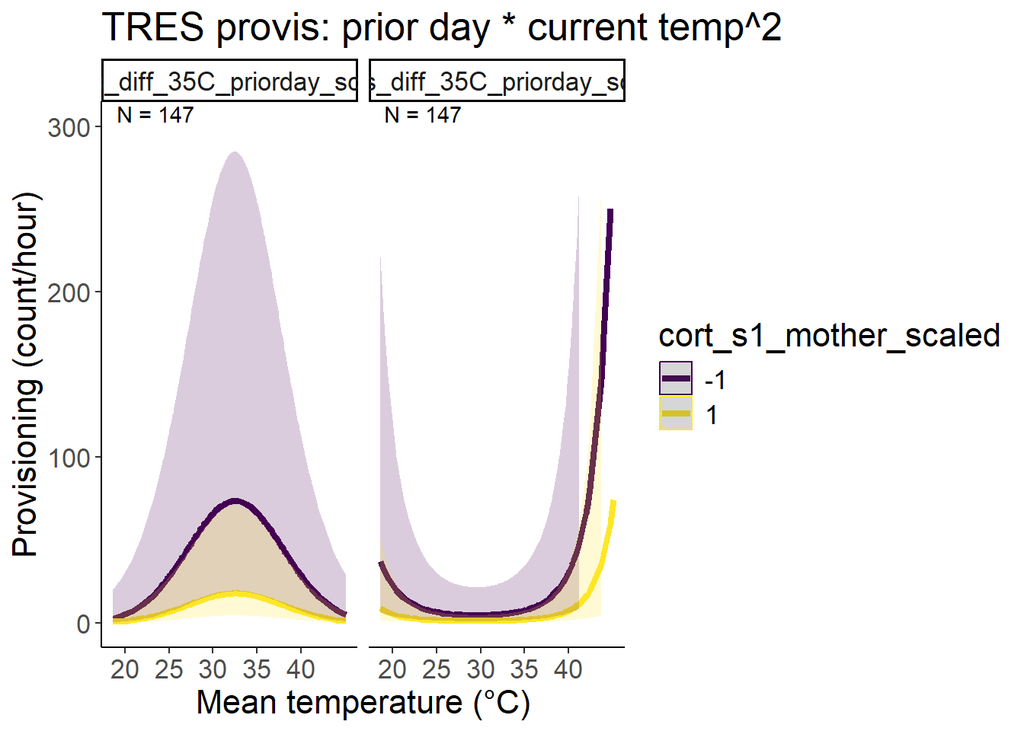

```r
data_tres_q4h3 = dplyr::filter(p,!is.na(mean_temp),
                                  # !is.na(julian_date),
                                  !is.na(mean_nestling_age),
                                  !is.na(deghours_diff_35C_priorday),
                                  !is.na(cort_s1_mother),
                                  !is.na(brood_size),
                                  !is.na(tod_h),
                                  !is.na(site),
                                  !is.na(attempt_id),
                                  !is.na(year_fct),
                                  species == "TRES"# ,
                                                # tod >= hms::as.hms('11:00:00', tz = "America/Los_Angeles"),
                                                # tod_end <= hms::as.hms('17:00:00',tz = "America/Los_Angeles"),
                                                # tod_end >= hms::as.hms('11:00:00', tz = "America/Los_Angeles")
                                                ) %>%
                        mutate(across(c(tod_h,mean_temp,deghours_diff_35C_priorday,cort_s1_mother,julian_date,mean_nestling_age,brood_size),
                                                    ~ scale(.x)[,1],
                                                    .names = "{.col}_scaled"))


mean_temp_tres_q4h3 <- mean(data_tres_q4h3 %>% pull(mean_temp))
sd_temp_tres_q4h3 <- sd(data_tres_q4h3 %>% pull(mean_temp))


temp_trans_tres_q4h3 <- trans_new("temp_trans_tres_q4h3",
                             transform = function(x){(x * sd_temp_tres_q4h3) + mean_temp_tres_q4h3},
                             inverse = function(x){x})

(figq4h3_tres <- predict_response(m_tres_q4h3,terms = c("mean_temp_scaled [all]","cort_s1_mother_scaled [-1,1]","deghours_diff_35C_priorday_scaled [-2,2]")) %>%
    plot(line_size = 1.5,alpha = .2,limit_range = TRUE,colors = "viridis") +
    # scale_color_hue(labels = c("Low","High")) +
    # aes(linetype = .data[["group"]]) +
    theme_classic() +
    # facet_wrap(~ group, ncol = 2) +
    xlab("Mean temperature (\u00b0C)") +
    ylab("Provisioning (count/hour)") +
    # scale_fill_viridis(discrete = TRUE) +
    # scale_color_viridis(discrete = TRUE) +
    theme(text = element_text(size = 16)) +
    labs(title =  "TRES provis: prior day * current temp^2") +
    scale_x_continuous(trans = temp_trans_tres_q4h3,
                       breaks = c((20-mean_temp_tres_q4h3)/sd_temp_tres_q4h3,
                                  (25-mean_temp_tres_q4h3)/sd_temp_tres_q4h3,
                                  (30-mean_temp_tres_q4h3)/sd_temp_tres_q4h3,
                                  (35-mean_temp_tres_q4h3)/sd_temp_tres_q4h3,
                                  (40-mean_temp_tres_q4h3)/sd_temp_tres_q4h3),
                       # breaks = c(20,30,40,50),
                       # labels = c("20","30","40","50"),
                       # limits = c((15-mean(g$meanmaxtempI,na.rm = TRUE))/sd(g$meanmaxtempI,na.rm = TRUE),
                       #            (55-mean(g$meanmaxtempI,na.rm = TRUE))/sd(g$meanmaxtempI,na.rm = TRUE))
                       # limits = c(18,5)
    ) +
    # scale_linetype_manual(values = "solid") +
    ylim(0,300) +
    geom_text(data = dat_text_tres_q4h3, mapping = aes(x = -Inf, y = Inf,label = label),hjust = -.2, vjust = 1.2,inherit.aes = FALSE) # +
    #theme(legend.position = "none")
)
```

```r
ggsave("../figures/provisbymaxtempxhab_TRES_q4h3.png",plot =  figq4h3_tres, width = 10, height = 6.6)
```

So, the salient interaction here is between mean temp and prior temp. When temps have been better prior, TRES are more responsive to temp. When it’s been worse, they’re less responsive to temp, and they provision less overall.

## Q4H4

4. (H4) Females with elevated stress-induced corticosterone concentrations would be less likely to maintain provisioning delivery to nestlings during hot periods after experiencing heat because elevated stress-induced corticosterone may be a sign that females are experiencing their environment as challenging. Prediction: positive cort * heat now2 * heat before term, because expectation is more “peaky” than lower-cort females

### WEBL

```r
m_WEBL <- glmmTMB(valid_detections ~ poly(mean_temp_scaled,2) * deghours_diff_35C_priorday_scaled * cort_s2_mother_scaled + mean_nestling_age_scaled + brood_size_scaled + year_fct +  (1|site:attempt_id),
           family = nbinom2(),
           ziformula = ~ 1,
           data = dplyr::filter(p,!is.na(mean_temp),
                                  # !is.na(julian_date),
                                  !is.na(mean_nestling_age),
                                  !is.na(deghours_diff_35C_priorday),
                                  !is.na(cort_s2_mother),
                                  !is.na(brood_size),
                                  !is.na(tod_h),
                                  !is.na(site),
                                  !is.na(attempt_id),
                                  !is.na(year_fct),
                                  species == "WEBL"# ,
                                                # tod >= hms::as.hms('11:00:00', tz = "America/Los_Angeles"),
                                                # tod_end <= hms::as.hms('17:00:00',tz = "America/Los_Angeles"),
                                                # tod_end >= hms::as.hms('11:00:00', tz = "America/Los_Angeles")
                                                ) %>%
                        mutate(across(c(tod_h,mean_temp,deghours_diff_35C_priorday,cort_s2_mother,julian_date,mean_nestling_age,brood_size),
                                                    ~ scale(.x)[,1],
                                                    .names = "{.col}_scaled")),
           )

m_WEBL_alldoubles <- glmmTMB(valid_detections ~ poly(mean_temp_scaled,2) * deghours_diff_35C_priorday_scaled + poly(mean_temp_scaled,2) * cort_s2_mother_scaled + deghours_diff_35C_priorday_scaled * cort_s2_mother_scaled + mean_nestling_age_scaled + brood_size_scaled + year_fct +  (1|site:attempt_id),
           family = nbinom2(),
           ziformula = ~ 1,
           data = dplyr::filter(p,!is.na(mean_temp),
                                  # !is.na(julian_date),
                                  !is.na(mean_nestling_age),
                                  !is.na(deghours_diff_35C_priorday),
                                  !is.na(cort_s2_mother),
                                  !is.na(brood_size),
                                  !is.na(tod_h),
                                  !is.na(site),
                                  !is.na(attempt_id),
                                  !is.na(year_fct),
                                  species == "WEBL"# ,
                                                # tod >= hms::as.hms('11:00:00', tz = "America/Los_Angeles"),
                                                # tod_end <= hms::as.hms('17:00:00',tz = "America/Los_Angeles"),
                                                # tod_end >= hms::as.hms('11:00:00', tz = "America/Los_Angeles")
                                                ) %>%
                        mutate(across(c(tod_h,mean_temp,deghours_diff_35C_priorday,cort_s2_mother,julian_date,mean_nestling_age,brood_size),
                                                    ~ scale(.x)[,1],
                                                    .names = "{.col}_scaled")),
           )

m_WEBL_deghxfc <- glmmTMB(valid_detections ~ poly(mean_temp_scaled,2) + deghours_diff_35C_priorday_scaled * cort_s2_mother_scaled + mean_nestling_age_scaled + brood_size_scaled + year_fct +  (1|site:attempt_id),
           family = nbinom2(),
           ziformula = ~ 1,
           data = dplyr::filter(p,!is.na(mean_temp),
                                  # !is.na(julian_date),
                                  !is.na(mean_nestling_age),
                                  !is.na(deghours_diff_35C_priorday),
                                  !is.na(cort_s2_mother),
                                  !is.na(brood_size),
                                  !is.na(tod_h),
                                  !is.na(site),
                                  !is.na(attempt_id),
                                  !is.na(year_fct),
                                  species == "WEBL"# ,
                                                # tod >= hms::as.hms('11:00:00', tz = "America/Los_Angeles"),
                                                # tod_end <= hms::as.hms('17:00:00',tz = "America/Los_Angeles"),
                                                # tod_end >= hms::as.hms('11:00:00', tz = "America/Los_Angeles")
                                                ) %>%
                        mutate(across(c(tod_h,mean_temp,deghours_diff_35C_priorday,cort_s2_mother,julian_date,mean_nestling_age,brood_size),
                                                    ~ scale(.x)[,1],
                                                    .names = "{.col}_scaled")),
           )

m_WEBL_mtxdegh <- glmmTMB(valid_detections ~ poly(mean_temp_scaled,2) * deghours_diff_35C_priorday_scaled + cort_s2_mother_scaled + mean_nestling_age_scaled + brood_size_scaled + year_fct +  (1|site:attempt_id),
           family = nbinom2(),
           ziformula = ~ 1,
           data = dplyr::filter(p,!is.na(mean_temp),
                                  # !is.na(julian_date),
                                  !is.na(mean_nestling_age),
                                  !is.na(deghours_diff_35C_priorday),
                                  !is.na(cort_s2_mother),
                                  !is.na(brood_size),
                                  !is.na(tod_h),
                                  !is.na(site),
                                  !is.na(attempt_id),
                                  !is.na(year_fct),
                                  species == "WEBL"# ,
                                                # tod >= hms::as.hms('11:00:00', tz = "America/Los_Angeles"),
                                                # tod_end <= hms::as.hms('17:00:00',tz = "America/Los_Angeles"),
                                                # tod_end >= hms::as.hms('11:00:00', tz = "America/Los_Angeles")
                                                ) %>%
                        mutate(across(c(tod_h,mean_temp,deghours_diff_35C_priorday,cort_s2_mother,julian_date,mean_nestling_age,brood_size),
                                                    ~ scale(.x)[,1],
                                                    .names = "{.col}_scaled")),
           )

m_WEBL_mtxfc <- glmmTMB(valid_detections ~ poly(mean_temp_scaled,2) * cort_s2_mother_scaled + deghours_diff_35C_priorday_scaled + mean_nestling_age_scaled + brood_size_scaled + year_fct +  (1|site:attempt_id),
           family = nbinom2(),
           ziformula = ~ 1,
           data = dplyr::filter(p,!is.na(mean_temp),
                                  # !is.na(julian_date),
                                  !is.na(mean_nestling_age),
                                  !is.na(deghours_diff_35C_priorday),
                                  !is.na(cort_s2_mother),
                                  !is.na(brood_size),
                                  !is.na(tod_h),
                                  !is.na(site),
                                  !is.na(attempt_id),
                                  !is.na(year_fct),
                                  species == "WEBL"# ,
                                                # tod >= hms::as.hms('11:00:00', tz = "America/Los_Angeles"),
                                                # tod_end <= hms::as.hms('17:00:00',tz = "America/Los_Angeles"),
                                                # tod_end >= hms::as.hms('11:00:00', tz = "America/Los_Angeles")
                                                ) %>%
                        mutate(across(c(tod_h,mean_temp,deghours_diff_35C_priorday,cort_s2_mother,julian_date,mean_nestling_age,brood_size),
                                                    ~ scale(.x)[,1],
                                                    .names = "{.col}_scaled")),
           )

m_WEBL_noint <- glmmTMB(valid_detections ~ poly(mean_temp_scaled,2) + deghours_diff_35C_priorday_scaled + cort_s2_mother_scaled + mean_nestling_age_scaled + brood_size_scaled + year_fct +  (1|site:attempt_id),
           family = nbinom2(),
           ziformula = ~ 1,
           data = dplyr::filter(p,!is.na(mean_temp),
                                  # !is.na(julian_date),
                                  !is.na(mean_nestling_age),
                                  !is.na(deghours_diff_35C_priorday),
                                  !is.na(cort_s2_mother),
                                  !is.na(brood_size),
                                  !is.na(tod_h),
                                  !is.na(site),
                                  !is.na(attempt_id),
                                  !is.na(year_fct),
                                  species == "WEBL"# ,
                                                # tod >= hms::as.hms('11:00:00', tz = "America/Los_Angeles"),
                                                # tod_end <= hms::as.hms('17:00:00',tz = "America/Los_Angeles"),
                                                # tod_end >= hms::as.hms('11:00:00', tz = "America/Los_Angeles")
                                                ) %>%
                        mutate(across(c(tod_h,mean_temp,deghours_diff_35C_priorday,cort_s2_mother,julian_date,mean_nestling_age,brood_size),
                                                    ~ scale(.x)[,1],
                                                    .names = "{.col}_scaled")),
           )

c <- anova(m_WEBL,m_WEBL_alldoubles,m_WEBL_mtxdegh,m_WEBL_deghxfc,m_WEBL_mtxfc) %>% tibble() %>% mutate(Model = c("Degree-hour * female condition","Mean temp * Degree-hour","Mean temp * female condition","All double interactions","Triple interaction"),.before = Df)

(tab <- c %>%
  as.tibble() %>%
  mutate(across(where(is.numeric),~round(.x,digits = 4)),
         P = `Pr(>Chisq)`) %>%
  dplyr::select(Model,AIC,Chisq,P) %>%
  mutate(across(c(AIC,Chisq), ~ round(.x, digits = 2)),
         P = if_else(P < 0.001,"<0.001",as.character(P))) %>% gt())
```

| Model | AIC | Chisq | P |
| --- | --- | --- | --- |
| Degree-hour * female condition | 868.25 | NA | NA |
| Mean temp * Degree-hour | 859.99 | 10.26 | 0.0014 |
| Mean temp * female condition | 868.25 | 0.00 | 1 |
| All double interactions | 863.53 | 10.71 | 0.0134 |
| Triple interaction | 846.34 | 21.19 | <0.001 |

```r
gtsave(tab,"../figures/int_tab_provis_ch3_q4h4_webl_1.html")

c <- anova(m_WEBL_alldoubles,m_WEBL_deghxfc,m_WEBL) %>% tibble() %>% mutate(Model = c("Degree-hour * cort s2","All double interactions","Triple interaction"),.before = Df)

(tab <- c %>%
  as.tibble() %>%
  mutate(across(where(is.numeric),~round(.x,digits = 4)),
         P = `Pr(>Chisq)`) %>%
  dplyr::select(Model,AIC,Chisq,P) %>%
  mutate(across(c(AIC,Chisq), ~ round(.x, digits = 2)),
         P = if_else(P < 0.001,"<0.001",as.character(P))) %>% gt())
```

| Model | AIC | Chisq | P |
| --- | --- | --- | --- |
| Degree-hour * cort s2 | 868.25 | NA | NA |
| All double interactions | 863.53 | 12.72 | 0.0128 |
| Triple interaction | 846.34 | 21.19 | <0.001 |

```r
gtsave(tab,"../figures/int_tab_provis_ch3_q4h4_webl_2.html")

summary(m_WEBL)
```

```
##  Family: nbinom2  ( log )
## Formula:
## valid_detections ~ poly(mean_temp_scaled, 2) * deghours_diff_35C_priorday_scaled *
##     cort_s2_mother_scaled + mean_nestling_age_scaled + brood_size_scaled +
##     year_fct + (1 | site:attempt_id)
## Zero inflation:                    ~1
## Data: dplyr::filter(p, !is.na(mean_temp), !is.na(mean_nestling_age),
##     !is.na(deghours_diff_35C_priorday), !is.na(cort_s2_mother),
##     !is.na(brood_size), !is.na(tod_h), !is.na(site), !is.na(attempt_id),
##     !is.na(year_fct), species == "WEBL") %>% mutate(across(c(tod_h,
##     mean_temp, deghours_diff_35C_priorday, cort_s2_mother, julian_date,
##     mean_nestling_age, brood_size), ~scale(.x)[, 1], .names = "{.col}_scaled"))
##
##      AIC      BIC   logLik deviance df.resid
##    846.3    900.7   -405.2    810.3      133
##
## Random effects:
##
## Conditional model:
##  Groups          Name        Variance Std.Dev.
##  site:attempt_id (Intercept) 0.2308   0.4804
## Number of obs: 151, groups:  site:attempt_id, 12
##
## Dispersion parameter for nbinom2 family (): 12.6
##
## Conditional model:
##                                                                                    Estimate
## (Intercept)                                                                         2.02239
## poly(mean_temp_scaled, 2)1                                                         -3.60302
## poly(mean_temp_scaled, 2)2                                                         -2.05028
## deghours_diff_35C_priorday_scaled                                                  -0.16659
## cort_s2_mother_scaled                                                              -0.02718
## mean_nestling_age_scaled                                                            0.24111
## brood_size_scaled                                                                   0.27842
## year_fct2023                                                                       -0.71111
## poly(mean_temp_scaled, 2)1:deghours_diff_35C_priorday_scaled                       -4.49570
## poly(mean_temp_scaled, 2)2:deghours_diff_35C_priorday_scaled                        1.38227
## poly(mean_temp_scaled, 2)1:cort_s2_mother_scaled                                    2.40946
## poly(mean_temp_scaled, 2)2:cort_s2_mother_scaled                                    3.45420
## deghours_diff_35C_priorday_scaled:cort_s2_mother_scaled                             0.70251
```

[output cut: 59 more lines]

```
## poly(mean_temp_scaled, 2)1:deghours_diff_35C_priorday_scaled                       **
## poly(mean_temp_scaled, 2)2:deghours_diff_35C_priorday_scaled
## poly(mean_temp_scaled, 2)1:cort_s2_mother_scaled                                   *
## poly(mean_temp_scaled, 2)2:cort_s2_mother_scaled                                   *
## deghours_diff_35C_priorday_scaled:cort_s2_mother_scaled                            ***
## poly(mean_temp_scaled, 2)1:deghours_diff_35C_priorday_scaled:cort_s2_mother_scaled ***
## poly(mean_temp_scaled, 2)2:deghours_diff_35C_priorday_scaled:cort_s2_mother_scaled
## ---
## Signif. codes:  0 '***' 0.001 '**' 0.01 '*' 0.05 '.' 0.1 ' ' 1
##
## Zero-inflation model:
##             Estimate Std. Error z value Pr(>|z|)
## (Intercept)   -3.331      0.747  -4.459 8.25e-06 ***
## ---
## Signif. codes:  0 '***' 0.001 '**' 0.01 '*' 0.05 '.' 0.1 ' ' 1
```

```r
m_webl_q4h4 <- m_WEBL

check_zeroinflation(m_WEBL)
```

```
## # Check for zero-inflation
##
##    Observed zeros: 15
##   Predicted zeros: 12
##             Ratio: 0.77
```

```
## Model is underfitting zeros (probable zero-inflation) (p = 0.448).
```

```r
# (t <- emtrends(m_webl_q1h1,specs = ~ habitat, var = c("mean_temp_scaled"),max.degree = 1) %>% test() %>%
#    mutate(across(where(is.numeric), ~ round(.x, digits = 3)),
#           df = round(df),
#           p.value = if_else(p.value == 0.000,"<0.001",as.character(p.value))) %>%
#    rename(Habitat = "habitat", `Max temp trend` = "mean_temp_scaled.trend",Df = "df", `Z-ratio` = "z.ratio", P = "p.value") %>%
#    #group_by(degree) %>%
#    gt())

ss_year_webl_provis_q4h4 <- m_webl_q4h4$frame %>%
  group_by(year_fct) %>%
  summarize(count_ind = n(),count_attempt = n_distinct(attempt_id)) %>%
  rowwise() %>%
  mutate(count = tibble(count_ind,count_attempt)) %>%
  dplyr::select(-c(count_ind, count_attempt)) %>%
  pivot_wider(values_from = count,names_from = year_fct) %>%
  as.tibble() %>% # rename(Habitat = 'habitat') %>%
  ungroup() %>%
  # mutate(`2021` = replace_na(`2021`,list(count_ind = 0,count_attempt = 0))) %>%
  mutate(Total = `2022` + `2023`) %>%
  rowwise() %>%
  mutate(`2022` = paste0(`2022`$count_ind,", ",`2022`$count_attempt),
         `2023` = paste0(`2023`$count_ind,", ",`2023`$count_attempt),
         Total = paste0(Total$count_ind,", ",Total$count_attempt)
  )

(t_ss_year_webl_provis_q4h4 <- ss_year_webl_provis_q4h4 %>% gt() %>%
    grand_summary_rows(fns = list(id = "Total") ~ {
      t <- str_split(.,", ",simplify = TRUE)
      t[,1] %>% as.numeric() %>% sum(na.rm = TRUE) %>% paste(t[,2] %>% as.numeric() %>% sum(na.rm = TRUE),sep = ", ")
    })
)
```

|  | 2022 | 2023 | Total |
| --- | --- | --- | --- |
|  | 88, 5 | 63, 7 | 151, 12 |
| Total | 88, 5 | 63, 7 | 151, 12 |

```r
t_ss_year_webl_provis_q4h4 %>% gtsave("../figures/ss_year_webl_provis_ch3_q4h4.html")

samp_q4h4 <- m_webl_q4h4$frame %>% summarize(count = n())
samp_q4h4 %>% gt() %>% gtsave("../figures/ss_webl_provis_ch3_q4h4.html")


dat_text_webl_q4h4 <- data.frame(
  label = paste("N =",samp_q4h4$count)# ,
  #group   = factor(c("Forest","Orchard","Grassland","Row crop"))
)

## num nestboxes
m_webl_q4h4$frame %>% pull(attempt_id) %>% unique() %>% length()
```

```
## [1] 12
```

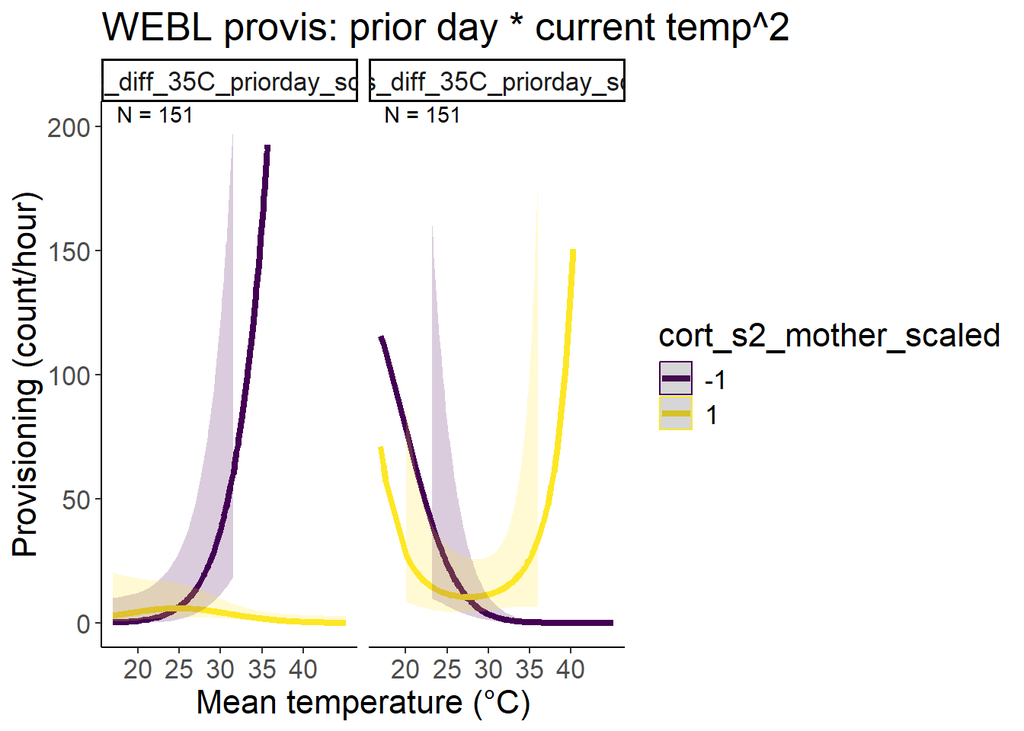

```r
data_webl_q4h4 = dplyr::filter(p,!is.na(mean_temp),
                                  # !is.na(julian_date),
                                  !is.na(mean_nestling_age),
                                  !is.na(deghours_diff_35C_priorday),
                                  !is.na(cort_s2_mother),
                                  !is.na(brood_size),
                                  !is.na(tod_h),
                                  !is.na(site),
                                  !is.na(attempt_id),
                                  !is.na(year_fct),
                                  species == "WEBL"# ,
                                                # tod >= hms::as.hms('11:00:00', tz = "America/Los_Angeles"),
                                                # tod_end <= hms::as.hms('17:00:00',tz = "America/Los_Angeles"),
                                                # tod_end >= hms::as.hms('11:00:00', tz = "America/Los_Angeles")
                                                ) %>%
                        mutate(across(c(tod_h,mean_temp,deghours_diff_35C_priorday,cort_s2_mother,julian_date,mean_nestling_age,brood_size),
                                                    ~ scale(.x)[,1],
                                                    .names = "{.col}_scaled"))


mean_temp_webl_q4h4 <- mean(data_webl_q4h4 %>% pull(mean_temp))
sd_temp_webl_q4h4 <- sd(data_webl_q4h4 %>% pull(mean_temp))


temp_trans_webl_q4h4 <- trans_new("temp_trans_webl_q4h4",
                             transform = function(x){(x * sd_temp_webl_q4h4) + mean_temp_webl_q4h4},
                             inverse = function(x){x})

(figq4h4_webl <- predict_response(m_webl_q4h4,terms = c("mean_temp_scaled [all]","cort_s2_mother_scaled [-1,1]","deghours_diff_35C_priorday_scaled [-2,2]")) %>%
    plot(line_size = 1.5,alpha = .2,limit_range = TRUE,colors = "viridis") +
    # scale_color_hue(labels = c("Low","High")) +
    # aes(linetype = .data[["group"]]) +
    theme_classic() +
    # facet_wrap(~ group, ncol = 2) +
    xlab("Mean temperature (\u00b0C)") +
    ylab("Provisioning (count/hour)") +
    # scale_fill_viridis(discrete = TRUE) +
    # scale_color_viridis(discrete = TRUE) +
    theme(text = element_text(size = 16)) +
    labs(title =  "WEBL provis: prior day * current temp^2") +
    scale_x_continuous(trans = temp_trans_webl_q4h4,
                       breaks = c((20-mean_temp_webl_q4h4)/sd_temp_webl_q4h4,
                                  (25-mean_temp_webl_q4h4)/sd_temp_webl_q4h4,
                                  (30-mean_temp_webl_q4h4)/sd_temp_webl_q4h4,
                                  (35-mean_temp_webl_q4h4)/sd_temp_webl_q4h4,
                                  (40-mean_temp_webl_q4h4)/sd_temp_webl_q4h4),
                       # breaks = c(20,30,40,50),
                       # labels = c("20","30","40","50"),
                       # limits = c((15-mean(g$meanmaxtempI,na.rm = TRUE))/sd(g$meanmaxtempI,na.rm = TRUE),
                       #            (55-mean(g$meanmaxtempI,na.rm = TRUE))/sd(g$meanmaxtempI,na.rm = TRUE))
                       # limits = c(18,5)
    ) +
    # scale_linetype_manual(values = "solid") +
    ylim(0,200) +
    geom_text(data = dat_text_webl_q4h4, mapping = aes(x = -Inf, y = Inf,label = label),hjust = -.2, vjust = 1.2,inherit.aes = FALSE) # +
    #theme(legend.position = "none")
)
```

```r
ggsave("../figures/provisbymaxtempxhab_WEBL_q4h4.png",plot =  figq4h4_webl, width = 10, height = 6.6)
```

### TRES

```r
m_TRES <- glmmTMB(valid_detections ~ poly(mean_temp_scaled,2) * deghours_diff_35C_priorday_scaled * cort_s2_mother_scaled + mean_nestling_age_scaled + brood_size_scaled + year_fct +  (1|site:attempt_id),
           family = nbinom2(),
           #ziformula = ~ 1,
           data = dplyr::filter(p,!is.na(mean_temp),
                                  # !is.na(julian_date),
                                  !is.na(mean_nestling_age),
                                  !is.na(deghours_diff_35C_priorday),
                                  !is.na(cort_s2_mother),
                                  !is.na(brood_size),
                                  !is.na(tod_h),
                                  !is.na(site),
                                  !is.na(attempt_id),
                                  !is.na(year_fct),
                                  species == "TRES"# ,
                                                # tod >= hms::as.hms('11:00:00', tz = "America/Los_Angeles"),
                                                # tod_end <= hms::as.hms('17:00:00',tz = "America/Los_Angeles"),
                                                # tod_end >= hms::as.hms('11:00:00', tz = "America/Los_Angeles")
                                                ) %>%
                        mutate(across(c(tod_h,mean_temp,deghours_diff_35C_priorday,cort_s2_mother,julian_date,mean_nestling_age,brood_size),
                                                    ~ scale(.x)[,1],
                                                    .names = "{.col}_scaled")),
           )

m_TRES_alldoubles <- glmmTMB(valid_detections ~ poly(mean_temp_scaled,2) * deghours_diff_35C_priorday_scaled + poly(mean_temp_scaled,2) * cort_s2_mother_scaled + deghours_diff_35C_priorday_scaled * cort_s2_mother_scaled + mean_nestling_age_scaled + brood_size_scaled + year_fct +  (1|site:attempt_id),
           family = nbinom2(),
           #ziformula = ~ 1,
           data = dplyr::filter(p,!is.na(mean_temp),
                                  # !is.na(julian_date),
                                  !is.na(mean_nestling_age),
                                  !is.na(deghours_diff_35C_priorday),
                                  !is.na(cort_s2_mother),
                                  !is.na(brood_size),
                                  !is.na(tod_h),
                                  !is.na(site),
                                  !is.na(attempt_id),
                                  !is.na(year_fct),
                                  species == "TRES"# ,
                                                # tod >= hms::as.hms('11:00:00', tz = "America/Los_Angeles"),
                                                # tod_end <= hms::as.hms('17:00:00',tz = "America/Los_Angeles"),
                                                # tod_end >= hms::as.hms('11:00:00', tz = "America/Los_Angeles")
                                                ) %>%
                        mutate(across(c(tod_h,mean_temp,deghours_diff_35C_priorday,cort_s2_mother,julian_date,mean_nestling_age,brood_size),
                                                    ~ scale(.x)[,1],
                                                    .names = "{.col}_scaled")),
           )

m_TRES_deghxfc <- glmmTMB(valid_detections ~ poly(mean_temp_scaled,2) + deghours_diff_35C_priorday_scaled * cort_s2_mother_scaled + mean_nestling_age_scaled + brood_size_scaled + year_fct +  (1|site:attempt_id),
           family = nbinom2(),
           #ziformula = ~ 1,
           data = dplyr::filter(p,!is.na(mean_temp),
                                  # !is.na(julian_date),
                                  !is.na(mean_nestling_age),
                                  !is.na(deghours_diff_35C_priorday),
                                  !is.na(cort_s2_mother),
                                  !is.na(brood_size),
                                  !is.na(tod_h),
                                  !is.na(site),
                                  !is.na(attempt_id),
                                  !is.na(year_fct),
                                  species == "TRES"# ,
                                                # tod >= hms::as.hms('11:00:00', tz = "America/Los_Angeles"),
                                                # tod_end <= hms::as.hms('17:00:00',tz = "America/Los_Angeles"),
                                                # tod_end >= hms::as.hms('11:00:00', tz = "America/Los_Angeles")
                                                ) %>%
                        mutate(across(c(tod_h,mean_temp,deghours_diff_35C_priorday,cort_s2_mother,julian_date,mean_nestling_age,brood_size),
                                                    ~ scale(.x)[,1],
                                                    .names = "{.col}_scaled")),
           )

m_TRES_mtxdegh <- glmmTMB(valid_detections ~ poly(mean_temp_scaled,2) * deghours_diff_35C_priorday_scaled + cort_s2_mother_scaled + mean_nestling_age_scaled + brood_size_scaled + year_fct +  (1|site:attempt_id),
           family = nbinom2(),
           #ziformula = ~ 1,
           data = dplyr::filter(p,!is.na(mean_temp),
                                  # !is.na(julian_date),
                                  !is.na(mean_nestling_age),
                                  !is.na(deghours_diff_35C_priorday),
                                  !is.na(cort_s2_mother),
                                  !is.na(brood_size),
                                  !is.na(tod_h),
                                  !is.na(site),
                                  !is.na(attempt_id),
                                  !is.na(year_fct),
                                  species == "TRES"# ,
                                                # tod >= hms::as.hms('11:00:00', tz = "America/Los_Angeles"),
                                                # tod_end <= hms::as.hms('17:00:00',tz = "America/Los_Angeles"),
                                                # tod_end >= hms::as.hms('11:00:00', tz = "America/Los_Angeles")
                                                ) %>%
                        mutate(across(c(tod_h,mean_temp,deghours_diff_35C_priorday,cort_s2_mother,julian_date,mean_nestling_age,brood_size),
                                                    ~ scale(.x)[,1],
                                                    .names = "{.col}_scaled")),
           )

m_TRES_mtxfc <- glmmTMB(valid_detections ~ poly(mean_temp_scaled,2) * cort_s2_mother_scaled + deghours_diff_35C_priorday_scaled + mean_nestling_age_scaled + brood_size_scaled + year_fct +  (1|site:attempt_id),
           family = nbinom2(),
           #ziformula = ~ 1,
           data = dplyr::filter(p,!is.na(mean_temp),
                                  # !is.na(julian_date),
                                  !is.na(mean_nestling_age),
                                  !is.na(deghours_diff_35C_priorday),
                                  !is.na(cort_s2_mother),
                                  !is.na(brood_size),
                                  !is.na(tod_h),
                                  !is.na(site),
                                  !is.na(attempt_id),
                                  !is.na(year_fct),
                                  species == "TRES"# ,
                                                # tod >= hms::as.hms('11:00:00', tz = "America/Los_Angeles"),
                                                # tod_end <= hms::as.hms('17:00:00',tz = "America/Los_Angeles"),
                                                # tod_end >= hms::as.hms('11:00:00', tz = "America/Los_Angeles")
                                                ) %>%
                        mutate(across(c(tod_h,mean_temp,deghours_diff_35C_priorday,cort_s2_mother,julian_date,mean_nestling_age,brood_size),
                                                    ~ scale(.x)[,1],
                                                    .names = "{.col}_scaled")),
           )

m_TRES_noint <- glmmTMB(valid_detections ~ poly(mean_temp_scaled,2) + deghours_diff_35C_priorday_scaled + cort_s2_mother_scaled + mean_nestling_age_scaled + brood_size_scaled + year_fct +  (1|site:attempt_id),
           family = nbinom2(),
           #ziformula = ~ 1,
           data = dplyr::filter(p,!is.na(mean_temp),
                                  # !is.na(julian_date),
                                  !is.na(mean_nestling_age),
                                  !is.na(deghours_diff_35C_priorday),
                                  !is.na(cort_s2_mother),
                                  !is.na(brood_size),
                                  !is.na(tod_h),
                                  !is.na(site),
                                  !is.na(attempt_id),
                                  !is.na(year_fct),
                                  species == "TRES"# ,
                                                # tod >= hms::as.hms('11:00:00', tz = "America/Los_Angeles"),
                                                # tod_end <= hms::as.hms('17:00:00',tz = "America/Los_Angeles"),
                                                # tod_end >= hms::as.hms('11:00:00', tz = "America/Los_Angeles")
                                                ) %>%
                        mutate(across(c(tod_h,mean_temp,deghours_diff_35C_priorday,cort_s2_mother,julian_date,mean_nestling_age,brood_size),
                                                    ~ scale(.x)[,1],
                                                    .names = "{.col}_scaled")),
           )

c <- anova(m_TRES,m_TRES_alldoubles,m_TRES_mtxdegh,m_TRES_deghxfc,m_TRES_mtxfc) %>% tibble() %>% mutate(Model = c("Degree-hour * female condition","Mean temp * Degree-hour","Mean temp * female condition","All double interactions","Triple interaction"),.before = Df)

(tab <- c %>%
  as.tibble() %>%
  mutate(across(where(is.numeric),~round(.x,digits = 4)),
         P = `Pr(>Chisq)`) %>%
  dplyr::select(Model,AIC,Chisq,P) %>%
  mutate(across(c(AIC,Chisq), ~ round(.x, digits = 2)),
         P = if_else(P < 0.001,"<0.001",as.character(P))) %>% gt())
```

| Model | AIC | Chisq | P |
| --- | --- | --- | --- |
| Degree-hour * female condition | 641.61 | NA | NA |
| Mean temp * Degree-hour | 645.52 | 0.00 | 1 |
| Mean temp * female condition | 644.56 | 0.96 | <0.001 |
| All double interactions | 639.66 | 10.90 | 0.0123 |
| Triple interaction | 638.88 | 4.78 | 0.0918 |

```r
gtsave(tab,"../figures/int_tab_provis_ch3_q4h4_tres_1.html")

c <- anova(m_TRES_mtxfc,m_TRES_alldoubles,m_TRES) %>% tibble() %>% mutate(Model = c("Mean temp * cort s2","All double interactions","Triple interaction"),.before = Df)

(tab <- c %>%
  as.tibble() %>%
  mutate(across(where(is.numeric),~round(.x,digits = 4)),
         P = `Pr(>Chisq)`) %>%
  dplyr::select(Model,AIC,Chisq,P) %>%
  mutate(across(c(AIC,Chisq), ~ round(.x, digits = 2)),
         P = if_else(P < 0.001,"<0.001",as.character(P))) %>% gt())
```

| Model | AIC | Chisq | P |
| --- | --- | --- | --- |
| Mean temp * cort s2 | 644.56 | NA | NA |
| All double interactions | 639.66 | 10.90 | 0.0123 |
| Triple interaction | 638.88 | 4.78 | 0.0918 |

```r
gtsave(tab,"../figures/int_tab_provis_ch3_q4h4_tres_2.html")

summary(m_TRES)
```

```
##  Family: nbinom2  ( log )
## Formula:
## valid_detections ~ poly(mean_temp_scaled, 2) * deghours_diff_35C_priorday_scaled *
##     cort_s2_mother_scaled + mean_nestling_age_scaled + brood_size_scaled +
##     year_fct + (1 | site:attempt_id)
## Data: dplyr::filter(p, !is.na(mean_temp), !is.na(mean_nestling_age),
##     !is.na(deghours_diff_35C_priorday), !is.na(cort_s2_mother),
##     !is.na(brood_size), !is.na(tod_h), !is.na(site), !is.na(attempt_id),
##     !is.na(year_fct), species == "TRES") %>% mutate(across(c(tod_h,
##     mean_temp, deghours_diff_35C_priorday, cort_s2_mother, julian_date,
##     mean_nestling_age, brood_size), ~scale(.x)[, 1], .names = "{.col}_scaled"))
##
##      AIC      BIC   logLik deviance df.resid
##    638.9    684.0   -302.4    604.9       88
##
## Random effects:
##
## Conditional model:
##  Groups          Name        Variance Std.Dev.
##  site:attempt_id (Intercept) 1.406    1.186
## Number of obs: 105, groups:  site:attempt_id, 10
##
## Dispersion parameter for nbinom2 family (): 3.55
##
## Conditional model:
##                                                                                    Estimate
## (Intercept)                                                                          1.5669
## poly(mean_temp_scaled, 2)1                                                          -3.9390
## poly(mean_temp_scaled, 2)2                                                           5.0055
## deghours_diff_35C_priorday_scaled                                                   -0.6039
## cort_s2_mother_scaled                                                               -1.2398
## mean_nestling_age_scaled                                                             0.1926
## brood_size_scaled                                                                    0.3854
## year_fct2023                                                                        -0.9473
## poly(mean_temp_scaled, 2)1:deghours_diff_35C_priorday_scaled                        -2.0751
## poly(mean_temp_scaled, 2)2:deghours_diff_35C_priorday_scaled                         7.9029
## poly(mean_temp_scaled, 2)1:cort_s2_mother_scaled                                   -11.8039
## poly(mean_temp_scaled, 2)2:cort_s2_mother_scaled                                     9.0470
## deghours_diff_35C_priorday_scaled:cort_s2_mother_scaled                             -1.1935
## poly(mean_temp_scaled, 2)1:deghours_diff_35C_priorday_scaled:cort_s2_mother_scaled  -7.5721
```

[output cut: 52 more lines]

```
## poly(mean_temp_scaled, 2)2                                                         *
## deghours_diff_35C_priorday_scaled
## cort_s2_mother_scaled
## mean_nestling_age_scaled
## brood_size_scaled
## year_fct2023
## poly(mean_temp_scaled, 2)1:deghours_diff_35C_priorday_scaled
## poly(mean_temp_scaled, 2)2:deghours_diff_35C_priorday_scaled                       **
## poly(mean_temp_scaled, 2)1:cort_s2_mother_scaled                                   *
## poly(mean_temp_scaled, 2)2:cort_s2_mother_scaled                                   *
## deghours_diff_35C_priorday_scaled:cort_s2_mother_scaled                            .
## poly(mean_temp_scaled, 2)1:deghours_diff_35C_priorday_scaled:cort_s2_mother_scaled .
## poly(mean_temp_scaled, 2)2:deghours_diff_35C_priorday_scaled:cort_s2_mother_scaled
## ---
## Signif. codes:  0 '***' 0.001 '**' 0.01 '*' 0.05 '.' 0.1 ' ' 1
```

```r
m_tres_q4h4 <- m_TRES

check_zeroinflation(m_TRES)
```

```
## # Check for zero-inflation
##
##    Observed zeros: 18
##   Predicted zeros: 18
##             Ratio: 1.00
```

```
## Model seems ok, ratio of observed and predicted zeros is within the
##   tolerance range (p = 0.944).
```

```r
# (t <- emtrends(m_tres_q1h1,specs = ~ habitat, var = c("mean_temp_scaled"),max.degree = 1) %>% test() %>%
#    mutate(across(where(is.numeric), ~ round(.x, digits = 3)),
#           df = round(df),
#           p.value = if_else(p.value == 0.000,"<0.001",as.character(p.value))) %>%
#    rename(Habitat = "habitat", `Max temp trend` = "mean_temp_scaled.trend",Df = "df", `Z-ratio` = "z.ratio", P = "p.value") %>%
#    #group_by(degree) %>%
#    gt())

ss_year_tres_provis_q4h4 <- m_tres_q4h4$frame %>%
  group_by(year_fct) %>%
  summarize(count_ind = n(),count_attempt = n_distinct(attempt_id)) %>%
  rowwise() %>%
  mutate(count = tibble(count_ind,count_attempt)) %>%
  dplyr::select(-c(count_ind, count_attempt)) %>%
  pivot_wider(values_from = count,names_from = year_fct) %>%
  as.tibble() %>% # rename(Habitat = 'habitat') %>%
  ungroup() %>%
  # mutate(`2021` = replace_na(`2021`,list(count_ind = 0,count_attempt = 0))) %>%
  mutate(Total = `2022` + `2023`) %>%
  rowwise() %>%
  mutate(`2022` = paste0(`2022`$count_ind,", ",`2022`$count_attempt),
         `2023` = paste0(`2023`$count_ind,", ",`2023`$count_attempt),
         Total = paste0(Total$count_ind,", ",Total$count_attempt)
  )

(t_ss_year_tres_provis_q4h4 <- ss_year_tres_provis_q4h4 %>% gt() %>%
    grand_summary_rows(fns = list(id = "Total") ~ {
      t <- str_split(.,", ",simplify = TRUE)
      t[,1] %>% as.numeric() %>% sum(na.rm = TRUE) %>% paste(t[,2] %>% as.numeric() %>% sum(na.rm = TRUE),sep = ", ")
    })
)
```

|  | 2022 | 2023 | Total |
| --- | --- | --- | --- |
|  | 45, 4 | 60, 6 | 105, 10 |
| Total | 45, 4 | 60, 6 | 105, 10 |

```r
t_ss_year_tres_provis_q4h4 %>% gtsave("../figures/ss_year_tres_provis_ch3_q4h4.html")

samp_q4h4 <- m_tres_q4h4$frame %>% summarize(count = n())
samp_q4h4 %>% gt() %>% gtsave("../figures/ss_tres_provis_ch3_q4h4.html")


dat_text_tres_q4h4 <- data.frame(
  label = paste("N =",samp_q4h4$count)# ,
  #group   = factor(c("Forest","Orchard","Grassland","Row crop"))
)

## num nestboxes
m_tres_q4h4$frame %>% pull(attempt_id) %>% unique() %>% length()
```

```
## [1] 10
```

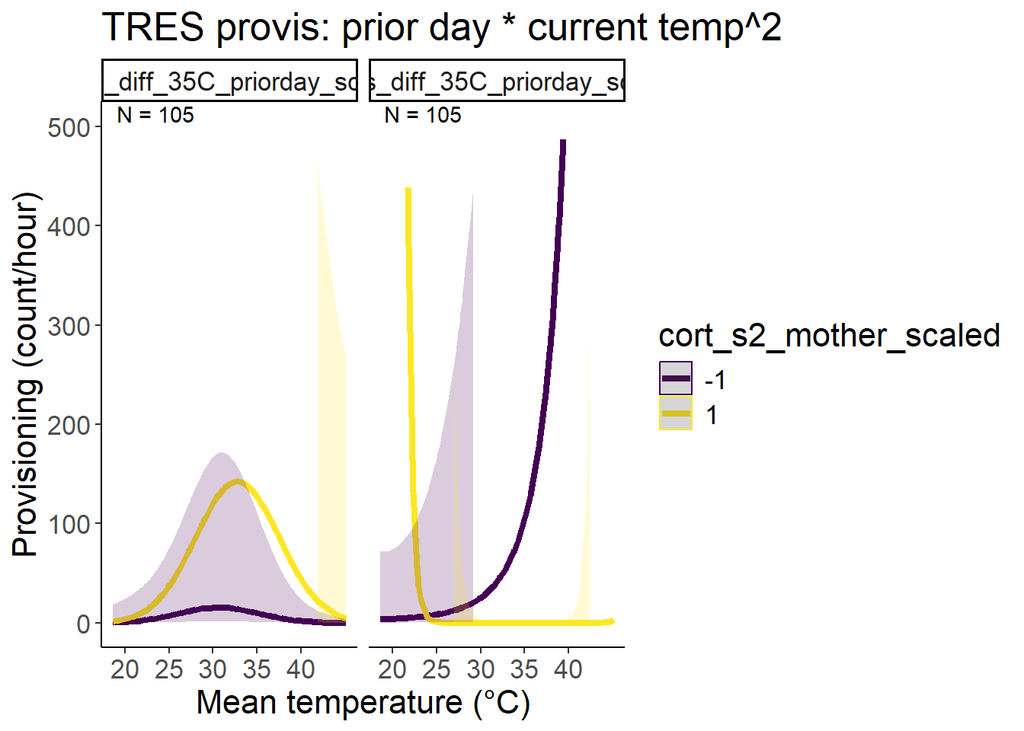

```r
data_tres_q4h4 = dplyr::filter(p,!is.na(mean_temp),
                                  # !is.na(julian_date),
                                  !is.na(mean_nestling_age),
                                  !is.na(deghours_diff_35C_priorday),
                                  !is.na(cort_s2_mother),
                                  !is.na(brood_size),
                                  !is.na(tod_h),
                                  !is.na(site),
                                  !is.na(attempt_id),
                                  !is.na(year_fct),
                                  species == "TRES"# ,
                                                # tod >= hms::as.hms('11:00:00', tz = "America/Los_Angeles"),
                                                # tod_end <= hms::as.hms('17:00:00',tz = "America/Los_Angeles"),
                                                # tod_end >= hms::as.hms('11:00:00', tz = "America/Los_Angeles")
                                                ) %>%
                        mutate(across(c(tod_h,mean_temp,deghours_diff_35C_priorday,cort_s2_mother,julian_date,mean_nestling_age,brood_size),
                                                    ~ scale(.x)[,1],
                                                    .names = "{.col}_scaled"))


mean_temp_tres_q4h4 <- mean(data_tres_q4h4 %>% pull(mean_temp))
sd_temp_tres_q4h4 <- sd(data_tres_q4h4 %>% pull(mean_temp))


temp_trans_tres_q4h4 <- trans_new("temp_trans_tres_q4h4",
                             transform = function(x){(x * sd_temp_tres_q4h4) + mean_temp_tres_q4h4},
                             inverse = function(x){x})

(figq4h4_tres <- predict_response(m_tres_q4h4,terms = c("mean_temp_scaled [all]","cort_s2_mother_scaled [-1,1]","deghours_diff_35C_priorday_scaled [-2,2]")) %>%
    plot(line_size = 1.5,alpha = .2,limit_range = TRUE,colors = "viridis") +
    # scale_color_hue(labels = c("Low","High")) +
    # aes(linetype = .data[["group"]]) +
    theme_classic() +
    # facet_wrap(~ group, ncol = 2) +
    xlab("Mean temperature (\u00b0C)") +
    ylab("Provisioning (count/hour)") +
    # scale_fill_viridis(discrete = TRUE) +
    # scale_color_viridis(discrete = TRUE) +
    theme(text = element_text(size = 16)) +
    labs(title =  "TRES provis: prior day * current temp^2") +
    scale_x_continuous(trans = temp_trans_tres_q4h4,
                       breaks = c((20-mean_temp_tres_q4h4)/sd_temp_tres_q4h4,
                                  (25-mean_temp_tres_q4h4)/sd_temp_tres_q4h4,
                                  (30-mean_temp_tres_q4h4)/sd_temp_tres_q4h4,
                                  (35-mean_temp_tres_q4h4)/sd_temp_tres_q4h4,
                                  (40-mean_temp_tres_q4h4)/sd_temp_tres_q4h4),
                       # breaks = c(20,30,40,50),
                       # labels = c("20","30","40","50"),
                       # limits = c((15-mean(g$meanmaxtempI,na.rm = TRUE))/sd(g$meanmaxtempI,na.rm = TRUE),
                       #            (55-mean(g$meanmaxtempI,na.rm = TRUE))/sd(g$meanmaxtempI,na.rm = TRUE))
                       # limits = c(18,5)
    ) +
    # scale_linetype_manual(values = "solid") +
    ylim(0,500) +
    geom_text(data = dat_text_tres_q4h4, mapping = aes(x = -Inf, y = Inf,label = label),hjust = -.2, vjust = 1.2,inherit.aes = FALSE) # +
    #theme(legend.position = "none")
)
```

```r
ggsave("../figures/provisbymaxtempxhab_TRES_q4h4.png",plot =  figq4h4_tres, width = 10, height = 6.6)
```

## Q5H1

How are body condition and cort related?

H1: Higher body condition means lower baseline cort H2: Higher body condition means lower stress-induced cort

```r
c <- read_rds("../data/cort_manytempmeasures.rds")
```

### WEBL

```r
m_WEBL <- lm(sqrt(mean_s1) ~ condition_scaled + brood_size_scaled + juliandate_scaled + year_fct + site,
           data = dplyr::filter(c,!is.na(condition),
                               condition < 1.9,
                                  # !is.na(julian_date),
                                  !is.na(brood_size),
                                  !is.na(juliandate),
                                  !is.na(site),
                                  !is.na(attempt_id),
                                  !is.na(year),
                                  species == "WEBL"# ,
                                                # tod >= hms::as.hms('11:00:00', tz = "America/Los_Angeles"),
                                                # tod_end <= hms::as.hms('17:00:00',tz = "America/Los_Angeles"),
                                                # tod_end >= hms::as.hms('11:00:00', tz = "America/Los_Angeles")
                                                ) %>%
                        mutate(across(c(condition,juliandate,brood_size),
                                                    ~ scale(.x)[,1],
                                                    .names = "{.col}_scaled")),
           )



summary(m_WEBL)
```

```
##
## Call:
## lm(formula = sqrt(mean_s1) ~ condition_scaled + brood_size_scaled +
##     juliandate_scaled + year_fct + site, data = dplyr::filter(c,
##     !is.na(condition), condition < 1.9, !is.na(brood_size), !is.na(juliandate),
##     !is.na(site), !is.na(attempt_id), !is.na(year), species ==
##         "WEBL") %>% mutate(across(c(condition, juliandate, brood_size),
##     ~scale(.x)[, 1], .names = "{.col}_scaled")))
##
## Residuals:
##      Min       1Q   Median       3Q      Max
## -0.92904 -0.36562 -0.04479  0.27766  1.10917
##
## Coefficients:
##                   Estimate Std. Error t value Pr(>|t|)
## (Intercept)        2.33499    0.20611  11.329 4.71e-09 ***
## condition_scaled   0.27874    0.17697   1.575   0.1348
## brood_size_scaled  0.27720    0.14185   1.954   0.0684 .
## juliandate_scaled  0.07209    0.16009   0.450   0.6585
## year_fct2023      -0.56748    0.35061  -1.619   0.1251
## sitePG             0.59974    0.28780   2.084   0.0536 .
## siteRR             0.62698    0.62916   0.997   0.3338
## ---
## Signif. codes:  0 '***' 0.001 '**' 0.01 '*' 0.05 '.' 0.1 ' ' 1
##
## Residual standard error: 0.5769 on 16 degrees of freedom
##   (10 observations deleted due to missingness)
## Multiple R-squared:  0.4433, Adjusted R-squared:  0.2346
## F-statistic: 2.124 on 6 and 16 DF,  p-value: 0.1071
```

```r
m_webl_q5h1 <- m_WEBL

(t <- emtrends(m_webl_q5h1, var = c("condition_scaled"),max.degree = 1) %>% test() %>%
   mutate(across(where(is.numeric), ~ round(.x, digits = 3)),
          df = round(df),
          p.value = if_else(p.value == 0.000,"<0.001",as.character(p.value))) %>%
   rename(`Max temp trend` = "condition_scaled.trend",Df = "df", `T-ratio` = "t.ratio", P = "p.value") %>%
   #group_by(degree) %>%
   gt())
```

| condition_scaled | brood_size_scaled | juliandate_scaled | year_fct | site | Max temp trend | SE | Df | T-ratio | P |
| --- | --- | --- | --- | --- | --- | --- | --- | --- | --- |
| -0.326 | -0.155 | 0.044 | 2022 | MB | 0.279 | 0.177 | 16 | 1.575 | 0.135 |
| -0.326 | -0.155 | 0.044 | 2023 | MB | 0.279 | 0.177 | 16 | 1.575 | 0.135 |
| -0.326 | -0.155 | 0.044 | 2022 | PG | 0.279 | 0.177 | 16 | 1.575 | 0.135 |
| -0.326 | -0.155 | 0.044 | 2023 | PG | 0.279 | 0.177 | 16 | 1.575 | 0.135 |
| -0.326 | -0.155 | 0.044 | 2022 | RR | 0.279 | 0.177 | 16 | 1.575 | 0.135 |
| -0.326 | -0.155 | 0.044 | 2023 | RR | 0.279 | 0.177 | 16 | 1.575 | 0.135 |

```r
gtsave(t,"../figures/weblprovistrend_ch3_q5h1.html")

data_webl_q5h1 = dplyr::filter(c,!is.na(condition),
                               condition < 1.9,
                                  # !is.na(julian_date),
                                  !is.na(brood_size),
                                  !is.na(juliandate),
                                  !is.na(site),
                                  !is.na(attempt_id),
                                  !is.na(year),
                                  species == "WEBL"# ,
                                                # tod >= hms::as.hms('11:00:00', tz = "America/Los_Angeles"),
                                                # tod_end <= hms::as.hms('17:00:00',tz = "America/Los_Angeles"),
                                                # tod_end >= hms::as.hms('11:00:00', tz = "America/Los_Angeles")
                                                ) %>%
                        mutate(across(c(condition,juliandate,brood_size),
                                                    ~ scale(.x)[,1],
                                                    .names = "{.col}_scaled"))

ss_year_webl_q5h1 <- data_webl_q5h1 %>%
  group_by(habitat,year_fct) %>%
  summarize(count_ind = n(),count_attempt = n_distinct(attempt_id)) %>%
  rowwise() %>%
  mutate(count = tibble(count_ind,count_attempt)) %>%
  dplyr::select(-c(count_ind, count_attempt)) %>%
  pivot_wider(values_from = count,names_from = year_fct) %>%
  as.tibble() %>% rename(Habitat = 'habitat') %>%
  ungroup() %>%
  # mutate(`2021` = replace_na(`2021`,list(count_ind = 0,count_attempt = 0))) %>%
  mutate(Total = `2022` + `2023`) %>%
  rowwise() %>%
  mutate(`2022` = paste0(`2022`$count_ind,", ",`2022`$count_attempt),
         `2023` = paste0(`2023`$count_ind,", ",`2023`$count_attempt),
         Total = paste0(Total$count_ind,", ",Total$count_attempt)
  )
(t_ss_year_webl_q5h1 <- ss_year_webl_q5h1 %>% gt() %>%
    grand_summary_rows(columns = -c(Habitat),fns = list(id = "Total") ~ {
      t <- str_split(.,", ",simplify = TRUE)
      t[,1] %>% as.numeric() %>% sum(na.rm = TRUE) %>% paste(t[,2] %>% as.numeric() %>% sum(na.rm = TRUE),sep = ", ")
    })
)
```

|  | Habitat | 2022 | 2023 | Total |
| --- | --- | --- | --- | --- |
|  | Forest | 4, 3 | 7, 6 | 11, 9 |
|  | Orchard | 5, 5 | 4, 3 | 9, 8 |
|  | Grassland | 5, 5 | 4, 3 | 9, 8 |
|  | Row crop | 2, 2 | 2, 2 | 4, 4 |
| Total | — | 16, 15 | 17, 14 | 33, 29 |

```r
t_ss_year_webl_q5h1 %>% gtsave("../figures/ss_year_webl_provis_ch3_q5h1.html")

samp <- data_webl_q5h1 %>% summarize(count = n())
samp %>% gt() %>% gtsave("../figures/ss_webl_ch3_q5h1.html")


dat_text_webl_q5h1 <- data.frame(
  label = paste("N =",samp$count),
  group   = factor(c("Forest","Orchard","Grassland","Row crop"))
)

## num nestboxes
data_webl_q5h1 %>% pull(attempt_id) %>% unique() %>% length()
```

```
## [1] 29
```

```
## Model has sqrt-transformed response. Back-transforming predictions to
##   original response scale. Standard errors are still on the transformed
## Data points may overlap. Use the `jitter` argument to add some amount of
##   random variation to the location of data points and avoid overplotting.
```

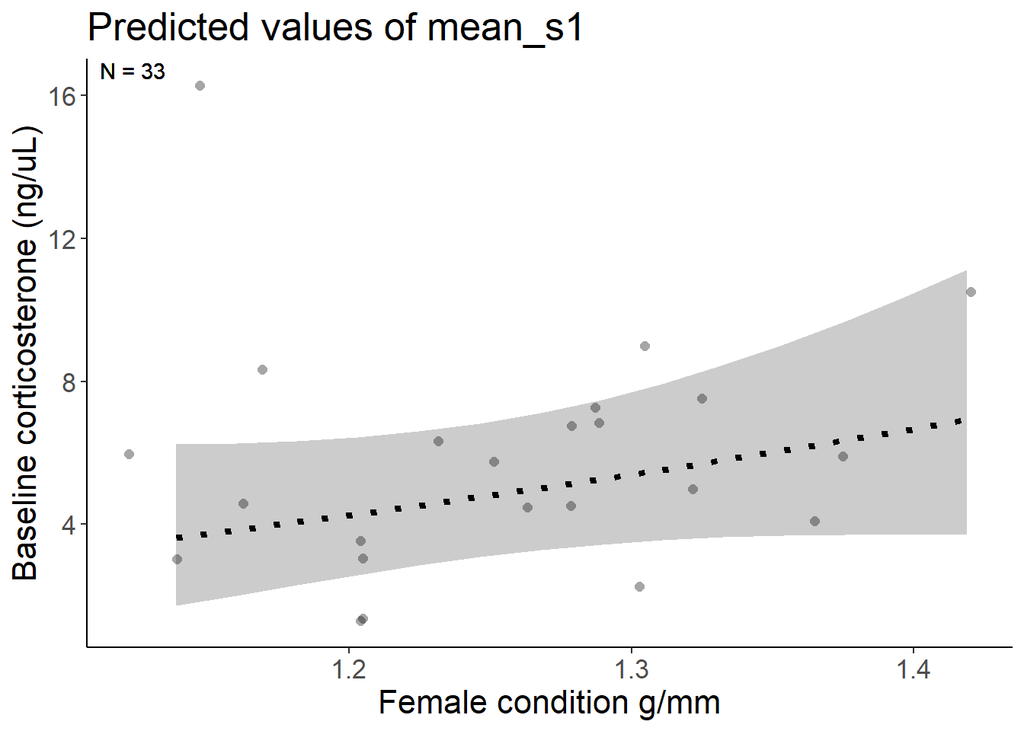

```r
mean_temp_webl_q5h1 <- mean(data_webl_q5h1 %>% pull(condition))
sd_temp_webl_q5h1 <- sd(data_webl_q5h1 %>% pull(condition))


temp_trans_webl_q5h1 <- trans_new("temp_trans_webl_q5h1",
                             transform = function(x){(x * sd_temp_webl_q5h1) + mean_temp_webl_q5h1},
                             inverse = function(x){x})

(figq5h1_webl <- predict_response(m_webl_q5h1,terms = c("condition_scaled")) %>%
    plot(line_size = 1.5,alpha = .2,show_data = TRUE,limit_range = TRUE) +
    aes(linetype = .data[["group"]]) +
    theme_classic() +
    # facet_wrap(~ group, ncol = 2) +
    xlab("Female condition g/mm") +
    ylab("Baseline corticosterone (ng/uL)") +
    scale_fill_viridis(discrete = TRUE) +
    scale_color_viridis(discrete = TRUE) +
    theme(text = element_text(size = 16)) +
    #labs(title =  "WEBL baseline cort: max * LC interaction") +
    scale_x_continuous(trans = temp_trans_webl_q5h1,
                       breaks = c((1-mean_temp_webl_q5h1)/sd_temp_webl_q5h1,
                                  (1.1-mean_temp_webl_q5h1)/sd_temp_webl_q5h1,
                                  (1.2-mean_temp_webl_q5h1)/sd_temp_webl_q5h1,
                                  (1.3-mean_temp_webl_q5h1)/sd_temp_webl_q5h1,
                                  (1.4-mean_temp_webl_q5h1)/sd_temp_webl_q5h1),
                       # breaks = c(20,30,40,50),
                       # labels = c("20","30","40","50"),
                       # limits = c((15-mean(g$meanmaxtempI,na.rm = TRUE))/sd(g$meanmaxtempI,na.rm = TRUE),
                       #            (55-mean(g$meanmaxtempI,na.rm = TRUE))/sd(g$meanmaxtempI,na.rm = TRUE))
                       # limits = c(18,5)
    ) +
    scale_linetype_manual(values = "dotted") +
    #ylim(-5,5) +
    geom_text(data = dat_text_webl_q5h1, mapping = aes(x = -Inf, y = Inf,label = label),hjust = -.2, vjust = 1.2,inherit.aes = FALSE) +
    theme(legend.position = "none")
)
```

```r
ggsave("../figures/provisbymaxtempxhab_WEBL_q5h1.png",plot =  figq5h1_webl, width = 10, height = 6.6)
```

### TRES

```r
m_TRES <- lm(sqrt(mean_s1) ~ condition_scaled + brood_size_scaled + juliandate_scaled + year_fct + site,
           data = dplyr::filter(c,!is.na(condition),
                               condition < 1.9,
                                  # !is.na(julian_date),
                                  !is.na(brood_size),
                                  !is.na(juliandate),
                                  !is.na(site),
                                  !is.na(attempt_id),
                                  !is.na(year),
                                  species == "TRES"# ,
                                                # tod >= hms::as.hms('11:00:00', tz = "America/Los_Angeles"),
                                                # tod_end <= hms::as.hms('17:00:00',tz = "America/Los_Angeles"),
                                                # tod_end >= hms::as.hms('11:00:00', tz = "America/Los_Angeles")
                                                ) %>%
                        mutate(across(c(condition,juliandate,brood_size),
                                                    ~ scale(.x)[,1],
                                                    .names = "{.col}_scaled")),
           )



summary(m_TRES)
```

```
##
## Call:
## lm(formula = sqrt(mean_s1) ~ condition_scaled + brood_size_scaled +
##     juliandate_scaled + year_fct + site, data = dplyr::filter(c,
##     !is.na(condition), condition < 1.9, !is.na(brood_size), !is.na(juliandate),
##     !is.na(site), !is.na(attempt_id), !is.na(year), species ==
##         "TRES") %>% mutate(across(c(condition, juliandate, brood_size),
##     ~scale(.x)[, 1], .names = "{.col}_scaled")))
##
## Residuals:
##     Min      1Q  Median      3Q     Max
## -0.6318 -0.2196  0.0357  0.2657  0.5575
##
## Coefficients:
##                   Estimate Std. Error t value Pr(>|t|)
## (Intercept)        1.40846    0.61064   2.307    0.050 *
## condition_scaled   0.11601    0.14814   0.783    0.456
## brood_size_scaled -0.07170    0.16738  -0.428    0.680
## juliandate_scaled -0.56177    0.44230  -1.270    0.240
## year_fct2023       1.19798    0.82944   1.444    0.187
## sitePG            -0.02429    0.32479  -0.075    0.942
## siteRR             0.34875    0.44830   0.778    0.459
## ---
## Signif. codes:  0 '***' 0.001 '**' 0.01 '*' 0.05 '.' 0.1 ' ' 1
##
## Residual standard error: 0.4824 on 8 degrees of freedom
## Multiple R-squared:  0.3538, Adjusted R-squared:  -0.1308
## F-statistic: 0.7301 on 6 and 8 DF,  p-value: 0.6394
```

```r
m_TRES_q5h1 <- m_TRES

(t <- emtrends(m_TRES_q5h1, var = c("condition_scaled"),max.degree = 1) %>% test() %>%
   mutate(across(where(is.numeric), ~ round(.x, digits = 3)),
          df = round(df),
          p.value = if_else(p.value == 0.000,"<0.001",as.character(p.value))) %>%
   rename(`Max temp trend` = "condition_scaled.trend",Df = "df", `T-ratio` = "t.ratio", P = "p.value") %>%
   #group_by(degree) %>%
   gt())
```

| condition_scaled | brood_size_scaled | juliandate_scaled | year_fct | site | Max temp trend | SE | Df | T-ratio | P |
| --- | --- | --- | --- | --- | --- | --- | --- | --- | --- |
| 0 | 0 | 0 | 2022 | MB | 0.116 | 0.148 | 8 | 0.783 | 0.456 |
| 0 | 0 | 0 | 2023 | MB | 0.116 | 0.148 | 8 | 0.783 | 0.456 |
| 0 | 0 | 0 | 2022 | PG | 0.116 | 0.148 | 8 | 0.783 | 0.456 |
| 0 | 0 | 0 | 2023 | PG | 0.116 | 0.148 | 8 | 0.783 | 0.456 |
| 0 | 0 | 0 | 2022 | RR | 0.116 | 0.148 | 8 | 0.783 | 0.456 |
| 0 | 0 | 0 | 2023 | RR | 0.116 | 0.148 | 8 | 0.783 | 0.456 |

```r
gtsave(t,"../figures/TRESprovistrend_ch3_q5h1.html")

data_TRES_q5h1 = dplyr::filter(c,!is.na(condition),
                               condition < 1.9,
                                  # !is.na(julian_date),
                                  !is.na(brood_size),
                                  !is.na(juliandate),
                                  !is.na(site),
                                  !is.na(attempt_id),
                                  !is.na(year),
                                  species == "TRES"# ,
                                                # tod >= hms::as.hms('11:00:00', tz = "America/Los_Angeles"),
                                                # tod_end <= hms::as.hms('17:00:00',tz = "America/Los_Angeles"),
                                                # tod_end >= hms::as.hms('11:00:00', tz = "America/Los_Angeles")
                                                ) %>%
                        mutate(across(c(condition,juliandate,brood_size),
                                                    ~ scale(.x)[,1],
                                                    .names = "{.col}_scaled"))

ss_year_TRES_q5h1 <- data_TRES_q5h1 %>%
  group_by(habitat,year_fct) %>%
  summarize(count_ind = n(),count_attempt = n_distinct(attempt_id)) %>%
  rowwise() %>%
  mutate(count = tibble(count_ind,count_attempt)) %>%
  dplyr::select(-c(count_ind, count_attempt)) %>%
  pivot_wider(values_from = count,names_from = year_fct) %>%
  as.tibble() %>% rename(Habitat = 'habitat') %>%
  ungroup() %>%
  # mutate(`2021` = replace_na(`2021`,list(count_ind = 0,count_attempt = 0))) %>%
  mutate(Total = `2022` + `2023`) %>%
  rowwise() %>%
  mutate(`2022` = paste0(`2022`$count_ind,", ",`2022`$count_attempt),
         `2023` = paste0(`2023`$count_ind,", ",`2023`$count_attempt),
         Total = paste0(Total$count_ind,", ",Total$count_attempt)
  )
(t_ss_year_TRES_q5h1 <- ss_year_TRES_q5h1 %>% gt() %>%
    grand_summary_rows(columns = -c(Habitat),fns = list(id = "Total") ~ {
      t <- str_split(.,", ",simplify = TRUE)
      t[,1] %>% as.numeric() %>% sum(na.rm = TRUE) %>% paste(t[,2] %>% as.numeric() %>% sum(na.rm = TRUE),sep = ", ")
    })
)
```

|  | Habitat | 2022 | 2023 | Total |
| --- | --- | --- | --- | --- |
|  | Forest | 1, 1 | 2, 2 | 3, 3 |
|  | Orchard | 1, 1 | NA, NA | NA, NA |
|  | Grassland | 3, 3 | 3, 3 | 6, 6 |
|  | Row crop | NA, NA | 5, 5 | NA, NA |
| Total | — | 5, 5 | 10, 10 | 9, 9 |

```r
t_ss_year_TRES_q5h1 %>% gtsave("../figures/ss_year_TRES_provis_ch3_q5h1.html")
samp <- data_TRES_q5h1 %>% summarize(count = n())
samp %>% gt() %>% gtsave("../figures/ss_TRES_ch3_q5h1.html")


dat_text_TRES_q5h1 <- data.frame(
  label = paste("N =",samp$count),
  group   = factor(c("Forest","Orchard","Grassland","Row crop"))
)

## num nestboxes
data_TRES_q5h1 %>% pull(attempt_id) %>% unique() %>% length()
```

```
## [1] 15
```

```
## Model has sqrt-transformed response. Back-transforming predictions to
##   original response scale. Standard errors are still on the transformed
## Data points may overlap. Use the `jitter` argument to add some amount of
##   random variation to the location of data points and avoid overplotting.
```

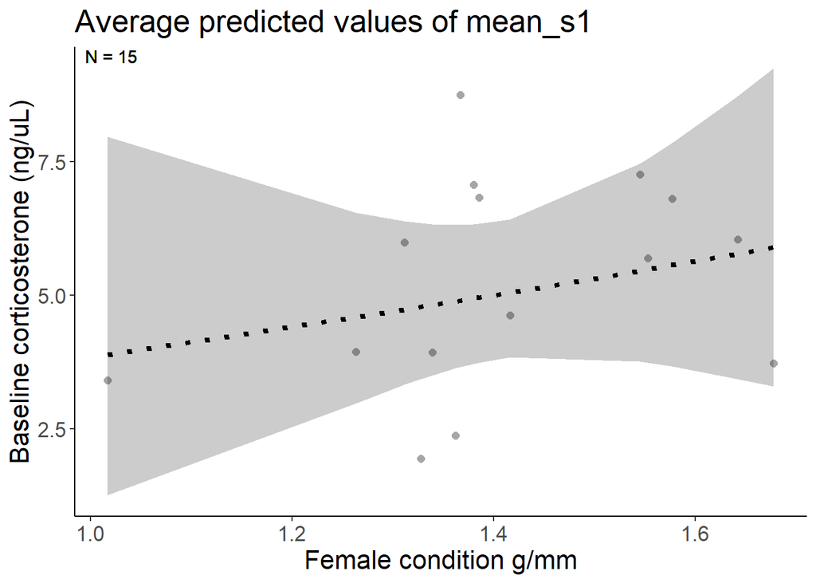

```r
mean_temp_TRES_q5h1 <- mean(data_TRES_q5h1 %>% pull(condition))
sd_temp_TRES_q5h1 <- sd(data_TRES_q5h1 %>% pull(condition))


temp_trans_TRES_q5h1 <- trans_new("temp_trans_TRES_q5h1",
                             transform = function(x){(x * sd_temp_TRES_q5h1) + mean_temp_TRES_q5h1},
                             inverse = function(x){x})

(figq5h1_TRES <- predict_response(m_TRES_q5h1,terms = c("condition_scaled"),margin = "empirical") %>%
    plot(line_size = 1.5,alpha = .2,show_data = TRUE,limit_range = TRUE) +
    aes(linetype = .data[["group"]]) +
    theme_classic() +
    # facet_wrap(~ group, ncol = 2) +
    xlab("Female condition g/mm") +
    ylab("Baseline corticosterone (ng/uL)") +
    scale_fill_viridis(discrete = TRUE) +
    scale_color_viridis(discrete = TRUE) +
    theme(text = element_text(size = 16)) +
    #labs(title =  "TRES baseline cort: max * LC interaction") +
    scale_x_continuous(trans = temp_trans_TRES_q5h1,
                       breaks = c((1-mean_temp_TRES_q5h1)/sd_temp_TRES_q5h1,
                                  (1.2-mean_temp_TRES_q5h1)/sd_temp_TRES_q5h1,
                                  (1.4-mean_temp_TRES_q5h1)/sd_temp_TRES_q5h1,
                                  (1.6-mean_temp_TRES_q5h1)/sd_temp_TRES_q5h1,
                                  (1.8-mean_temp_TRES_q5h1)/sd_temp_TRES_q5h1),
                       # breaks = c(20,30,40,50),
                       # labels = c("20","30","40","50"),
                       # limits = c((15-mean(g$meanmaxtempI,na.rm = TRUE))/sd(g$meanmaxtempI,na.rm = TRUE),
                       #            (55-mean(g$meanmaxtempI,na.rm = TRUE))/sd(g$meanmaxtempI,na.rm = TRUE))
                       # limits = c(18,5)
    ) +
    scale_linetype_manual(values = "dotted") +
    #ylim(-5,5) +
    geom_text(data = dat_text_TRES_q5h1, mapping = aes(x = -Inf, y = Inf,label = label),hjust = -.2, vjust = 1.2,inherit.aes = FALSE) +
    theme(legend.position = "none")
)
```

```r
ggsave("../figures/provisbymaxtempxhab_TRES_q5h1.png",plot =  figq5h1_TRES, width = 10, height = 6.6)
```

## Q5H2

### WEBL

```r
m_WEBL <- lm(sqrt(mean_s2) ~ condition_scaled + brood_size_scaled + juliandate_scaled + year_fct + site,
           data = dplyr::filter(c,!is.na(condition),
                               condition < 1.9,
                                  # !is.na(julian_date),
                                  !is.na(brood_size),
                                  !is.na(juliandate),
                                  !is.na(site),
                                  !is.na(attempt_id),
                                  !is.na(year),
                                  species == "WEBL"# ,
                                                # tod >= hms::as.hms('11:00:00', tz = "America/Los_Angeles"),
                                                # tod_end <= hms::as.hms('17:00:00',tz = "America/Los_Angeles"),
                                                # tod_end >= hms::as.hms('11:00:00', tz = "America/Los_Angeles")
                                                ) %>%
                        mutate(across(c(condition,juliandate,brood_size),
                                                    ~ scale(.x)[,1],
                                                    .names = "{.col}_scaled")),
           )



summary(m_WEBL)
```

```
##
## Call:
## lm(formula = sqrt(mean_s2) ~ condition_scaled + brood_size_scaled +
##     juliandate_scaled + year_fct + site, data = dplyr::filter(c,
##     !is.na(condition), condition < 1.9, !is.na(brood_size), !is.na(juliandate),
##     !is.na(site), !is.na(attempt_id), !is.na(year), species ==
##         "WEBL") %>% mutate(across(c(condition, juliandate, brood_size),
##     ~scale(.x)[, 1], .names = "{.col}_scaled")))
##
## Residuals:
##     Min      1Q  Median      3Q     Max
## -2.1863 -0.9383 -0.2228  0.9707  2.6668
##
## Coefficients:
##                   Estimate Std. Error t value Pr(>|t|)
## (Intercept)         5.4927     0.4973  11.045  5.8e-10 ***
## condition_scaled   -0.5792     0.3465  -1.672    0.110
## brood_size_scaled   0.2081     0.3636   0.572    0.573
## juliandate_scaled   0.2056     0.3924   0.524    0.606
## year_fct2023       -1.1390     0.8348  -1.364    0.188
## sitePG              0.1608     0.7111   0.226    0.823
## siteRR              0.5452     1.2656   0.431    0.671
## ---
## Signif. codes:  0 '***' 0.001 '**' 0.01 '*' 0.05 '.' 0.1 ' ' 1
##
## Residual standard error: 1.491 on 20 degrees of freedom
##   (6 observations deleted due to missingness)
## Multiple R-squared:  0.3388, Adjusted R-squared:  0.1404
## F-statistic: 1.708 on 6 and 20 DF,  p-value: 0.171
```

```r
m_webl_q5h2 <- m_WEBL

(t <- emtrends(m_webl_q5h2, var = c("condition_scaled"),max.degree = 1) %>% test() %>%
   mutate(across(where(is.numeric), ~ round(.x, digits = 3)),
          df = round(df),
          p.value = if_else(p.value == 0.000,"<0.001",as.character(p.value))) %>%
   rename(`Max temp trend` = "condition_scaled.trend",Df = "df", `T-ratio` = "t.ratio", P = "p.value") %>%
   #group_by(degree) %>%
   gt())
```

| condition_scaled | brood_size_scaled | juliandate_scaled | year_fct | site | Max temp trend | SE | Df | T-ratio | P |
| --- | --- | --- | --- | --- | --- | --- | --- | --- | --- |
| 0.017 | 0.075 | -0.143 | 2022 | MB | -0.579 | 0.347 | 20 | -1.672 | 0.11 |
| 0.017 | 0.075 | -0.143 | 2023 | MB | -0.579 | 0.347 | 20 | -1.672 | 0.11 |
| 0.017 | 0.075 | -0.143 | 2022 | PG | -0.579 | 0.347 | 20 | -1.672 | 0.11 |
| 0.017 | 0.075 | -0.143 | 2023 | PG | -0.579 | 0.347 | 20 | -1.672 | 0.11 |
| 0.017 | 0.075 | -0.143 | 2022 | RR | -0.579 | 0.347 | 20 | -1.672 | 0.11 |
| 0.017 | 0.075 | -0.143 | 2023 | RR | -0.579 | 0.347 | 20 | -1.672 | 0.11 |

```r
gtsave(t,"../figures/weblprovistrend_ch3_q5h2.html")

data_webl_q5h2 = dplyr::filter(c,!is.na(condition),
                               condition < 1.9,
                                  # !is.na(julian_date),
                                  !is.na(brood_size),
                                  !is.na(juliandate),
                                  !is.na(site),
                                  !is.na(attempt_id),
                                  !is.na(year),
                                  species == "WEBL"# ,
                                                # tod >= hms::as.hms('11:00:00', tz = "America/Los_Angeles"),
                                                # tod_end <= hms::as.hms('17:00:00',tz = "America/Los_Angeles"),
                                                # tod_end >= hms::as.hms('11:00:00', tz = "America/Los_Angeles")
                                                ) %>%
                        mutate(across(c(condition,juliandate,brood_size),
                                                    ~ scale(.x)[,1],
                                                    .names = "{.col}_scaled"))

ss_year_webl_q5h2 <- data_webl_q5h2 %>%
  group_by(habitat,year_fct) %>%
  summarize(count_ind = n(),count_attempt = n_distinct(attempt_id)) %>%
  rowwise() %>%
  mutate(count = tibble(count_ind,count_attempt)) %>%
  dplyr::select(-c(count_ind, count_attempt)) %>%
  pivot_wider(values_from = count,names_from = year_fct) %>%
  as.tibble() %>% rename(Habitat = 'habitat') %>%
  ungroup() %>%
  # mutate(`2021` = replace_na(`2021`,list(count_ind = 0,count_attempt = 0))) %>%
  mutate(Total = `2022` + `2023`) %>%
  rowwise() %>%
  mutate(`2022` = paste0(`2022`$count_ind,", ",`2022`$count_attempt),
         `2023` = paste0(`2023`$count_ind,", ",`2023`$count_attempt),
         Total = paste0(Total$count_ind,", ",Total$count_attempt)
  )
(t_ss_year_webl_q5h2 <- ss_year_webl_q5h2 %>% gt() %>%
    grand_summary_rows(columns = -c(Habitat),fns = list(id = "Total") ~ {
      t <- str_split(.,", ",simplify = TRUE)
      t[,1] %>% as.numeric() %>% sum(na.rm = TRUE) %>% paste(t[,2] %>% as.numeric() %>% sum(na.rm = TRUE),sep = ", ")
    })
)
```

|  | Habitat | 2022 | 2023 | Total |
| --- | --- | --- | --- | --- |
|  | Forest | 4, 3 | 7, 6 | 11, 9 |
|  | Orchard | 5, 5 | 4, 3 | 9, 8 |
|  | Grassland | 5, 5 | 4, 3 | 9, 8 |
|  | Row crop | 2, 2 | 2, 2 | 4, 4 |
| Total | — | 16, 15 | 17, 14 | 33, 29 |

```r
t_ss_year_webl_q5h2 %>% gtsave("../figures/ss_year_webl_provis_ch3_q5h2.html")

samp <- data_webl_q5h2 %>% summarize(count = n())
samp %>% gt() %>% gtsave("../figures/ss_webl_ch3_q5h2.html")


dat_text_webl_q5h2 <- data.frame(
  label = paste("N =",samp$count),
  group   = factor(c("Forest","Orchard","Grassland","Row crop"))
)

## num nestboxes
data_webl_q5h2 %>% pull(attempt_id) %>% unique() %>% length()
```

```
## [1] 29
```

```
## Model has sqrt-transformed response. Back-transforming predictions to
##   original response scale. Standard errors are still on the transformed
## Data points may overlap. Use the `jitter` argument to add some amount of
##   random variation to the location of data points and avoid overplotting.
```

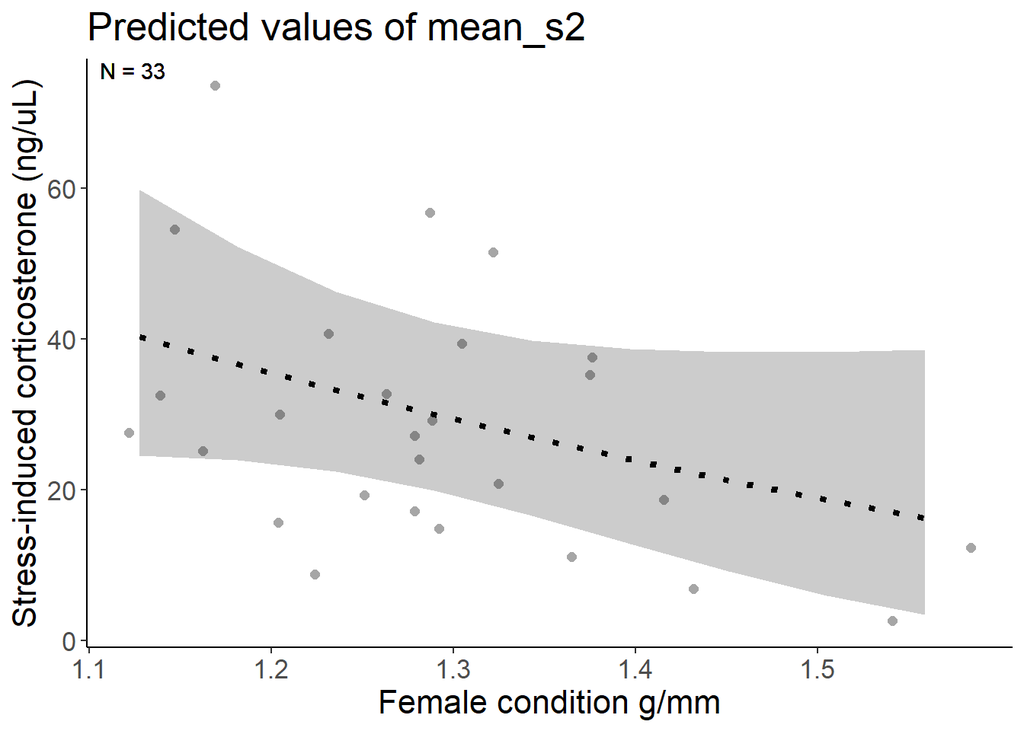

```r
mean_temp_webl_q5h2 <- mean(data_webl_q5h2 %>% pull(condition))
sd_temp_webl_q5h2 <- sd(data_webl_q5h2 %>% pull(condition))


temp_trans_webl_q5h2 <- trans_new("temp_trans_webl_q5h2",
                             transform = function(x){(x * sd_temp_webl_q5h2) + mean_temp_webl_q5h2},
                             inverse = function(x){x})

(figq5h2_webl <- predict_response(m_webl_q5h2,terms = c("condition_scaled")) %>%
    plot(line_size = 1.5,alpha = .2,show_data = TRUE,limit_range = TRUE) +
    aes(linetype = .data[["group"]]) +
    theme_classic() +
    # facet_wrap(~ group, ncol = 2) +
    xlab("Female condition g/mm") +
    ylab("Stress-induced corticosterone (ng/uL)") +
    scale_fill_viridis(discrete = TRUE) +
    scale_color_viridis(discrete = TRUE) +
    theme(text = element_text(size = 16)) +
    #labs(title =  "WEBL baseline cort: max * LC interaction") +
    scale_x_continuous(trans = temp_trans_webl_q5h2,
                       breaks = c((1.1-mean_temp_webl_q5h2)/sd_temp_webl_q5h2,
                                  (1.2-mean_temp_webl_q5h2)/sd_temp_webl_q5h2,
                                  (1.3-mean_temp_webl_q5h2)/sd_temp_webl_q5h2,
                                  (1.4-mean_temp_webl_q5h2)/sd_temp_webl_q5h2,
                                  (1.5-mean_temp_webl_q5h2)/sd_temp_webl_q5h2),
                       # breaks = c(20,30,40,50),
                       # labels = c("20","30","40","50"),
                       # limits = c((15-mean(g$meanmaxtempI,na.rm = TRUE))/sd(g$meanmaxtempI,na.rm = TRUE),
                       #            (55-mean(g$meanmaxtempI,na.rm = TRUE))/sd(g$meanmaxtempI,na.rm = TRUE))
                       # limits = c(18,5)
    ) +
    scale_linetype_manual(values = "dotted") +
    #ylim(-5,5) +
    geom_text(data = dat_text_webl_q5h2, mapping = aes(x = -Inf, y = Inf,label = label),hjust = -.2, vjust = 1.2,inherit.aes = FALSE) +
    theme(legend.position = "none")
)
```

```r
ggsave("../figures/provisbymaxtempxhab_WEBL_q5h2.png",plot =  figq5h2_webl, width = 10, height = 6.6)
```

### TRES

```r
m_TRES <- lm(sqrt(mean_s2) ~ condition_scaled + brood_size_scaled + juliandate_scaled + year_fct + site,
           data = dplyr::filter(c,!is.na(condition),
                               condition < 1.9,
                                  # !is.na(julian_date),
                                  !is.na(brood_size),
                                  !is.na(juliandate),
                                  !is.na(site),
                                  !is.na(attempt_id),
                                  !is.na(year),
                                  species == "TRES"# ,
                                                # tod >= hms::as.hms('11:00:00', tz = "America/Los_Angeles"),
                                                # tod_end <= hms::as.hms('17:00:00',tz = "America/Los_Angeles"),
                                                # tod_end >= hms::as.hms('11:00:00', tz = "America/Los_Angeles")
                                                ) %>%
                        mutate(across(c(condition,juliandate,brood_size),
                                                    ~ scale(.x)[,1],
                                                    .names = "{.col}_scaled")),
           )



summary(m_TRES)
```

```
##
## Call:
## lm(formula = sqrt(mean_s2) ~ condition_scaled + brood_size_scaled +
##     juliandate_scaled + year_fct + site, data = dplyr::filter(c,
##     !is.na(condition), condition < 1.9, !is.na(brood_size), !is.na(juliandate),
##     !is.na(site), !is.na(attempt_id), !is.na(year), species ==
##         "TRES") %>% mutate(across(c(condition, juliandate, brood_size),
##     ~scale(.x)[, 1], .names = "{.col}_scaled")))
##
## Residuals:
##      Min       1Q   Median       3Q      Max
## -0.97833 -0.36208  0.09727  0.35378  0.94350
##
## Coefficients:
##                   Estimate Std. Error t value Pr(>|t|)
## (Intercept)         6.0975     0.9429   6.467 0.000195 ***
## condition_scaled   -0.1484     0.2287  -0.649 0.534613
## brood_size_scaled  -0.3449     0.2584  -1.334 0.218812
## juliandate_scaled   0.8166     0.6829   1.196 0.266051
## year_fct2023       -2.1386     1.2807  -1.670 0.133498
## sitePG              0.4692     0.5015   0.936 0.376832
## siteRR              1.6221     0.6922   2.343 0.047164 *
## ---
## Signif. codes:  0 '***' 0.001 '**' 0.01 '*' 0.05 '.' 0.1 ' ' 1
##
## Residual standard error: 0.7448 on 8 degrees of freedom
## Multiple R-squared:  0.6389, Adjusted R-squared:  0.3681
## F-statistic: 2.359 on 6 and 8 DF,  p-value: 0.1298
```

```r
m_TRES_q5h2 <- m_TRES

(t <- emtrends(m_TRES_q5h2, var = c("condition_scaled"),max.degree = 1) %>% test() %>%
   mutate(across(where(is.numeric), ~ round(.x, digits = 3)),
          df = round(df),
          p.value = if_else(p.value == 0.000,"<0.001",as.character(p.value))) %>%
   rename(`Max temp trend` = "condition_scaled.trend",Df = "df", `T-ratio` = "t.ratio", P = "p.value") %>%
   #group_by(degree) %>%
   gt())
```

| condition_scaled | brood_size_scaled | juliandate_scaled | year_fct | site | Max temp trend | SE | Df | T-ratio | P |
| --- | --- | --- | --- | --- | --- | --- | --- | --- | --- |
| 0 | 0 | 0 | 2022 | MB | -0.148 | 0.229 | 8 | -0.649 | 0.535 |
| 0 | 0 | 0 | 2023 | MB | -0.148 | 0.229 | 8 | -0.649 | 0.535 |
| 0 | 0 | 0 | 2022 | PG | -0.148 | 0.229 | 8 | -0.649 | 0.535 |
| 0 | 0 | 0 | 2023 | PG | -0.148 | 0.229 | 8 | -0.649 | 0.535 |
| 0 | 0 | 0 | 2022 | RR | -0.148 | 0.229 | 8 | -0.649 | 0.535 |
| 0 | 0 | 0 | 2023 | RR | -0.148 | 0.229 | 8 | -0.649 | 0.535 |

```r
gtsave(t,"../figures/TRESprovistrend_ch3_q5h2.html")

data_TRES_q5h2 = dplyr::filter(c,!is.na(condition),
                               condition < 1.9,
                                  # !is.na(julian_date),
                                  !is.na(brood_size),
                                  !is.na(juliandate),
                                  !is.na(site),
                                  !is.na(attempt_id),
                                  !is.na(year),
                                  species == "TRES"# ,
                                                # tod >= hms::as.hms('11:00:00', tz = "America/Los_Angeles"),
                                                # tod_end <= hms::as.hms('17:00:00',tz = "America/Los_Angeles"),
                                                # tod_end >= hms::as.hms('11:00:00', tz = "America/Los_Angeles")
                                                ) %>%
                        mutate(across(c(condition,juliandate,brood_size),
                                                    ~ scale(.x)[,1],
                                                    .names = "{.col}_scaled"))

ss_year_TRES_q5h2 <- data_TRES_q5h2 %>%
  group_by(habitat,year_fct) %>%
  summarize(count_ind = n(),count_attempt = n_distinct(attempt_id)) %>%
  rowwise() %>%
  mutate(count = tibble(count_ind,count_attempt)) %>%
  dplyr::select(-c(count_ind, count_attempt)) %>%
  pivot_wider(values_from = count,names_from = year_fct) %>%
  as.tibble() %>% rename(Habitat = 'habitat') %>%
  ungroup() %>%
  # mutate(`2021` = replace_na(`2021`,list(count_ind = 0,count_attempt = 0))) %>%
  mutate(Total = `2022` + `2023`) %>%
  rowwise() %>%
  mutate(`2022` = paste0(`2022`$count_ind,", ",`2022`$count_attempt),
         `2023` = paste0(`2023`$count_ind,", ",`2023`$count_attempt),
         Total = paste0(Total$count_ind,", ",Total$count_attempt)
  )
(t_ss_year_TRES_q5h2 <- ss_year_TRES_q5h2 %>% gt() %>%
    grand_summary_rows(columns = -c(Habitat),fns = list(id = "Total") ~ {
      t <- str_split(.,", ",simplify = TRUE)
      t[,1] %>% as.numeric() %>% sum(na.rm = TRUE) %>% paste(t[,2] %>% as.numeric() %>% sum(na.rm = TRUE),sep = ", ")
    })
)
```

|  | Habitat | 2022 | 2023 | Total |
| --- | --- | --- | --- | --- |
|  | Forest | 1, 1 | 2, 2 | 3, 3 |
|  | Orchard | 1, 1 | NA, NA | NA, NA |
|  | Grassland | 3, 3 | 3, 3 | 6, 6 |
|  | Row crop | NA, NA | 5, 5 | NA, NA |
| Total | — | 5, 5 | 10, 10 | 9, 9 |

```r
t_ss_year_TRES_q5h2 %>% gtsave("../figures/ss_year_TRES_provis_ch3_q5h2.html")
samp <- data_TRES_q5h2 %>% summarize(count = n())
samp %>% gt() %>% gtsave("../figures/ss_TRES_ch3_q5h2.html")


dat_text_TRES_q5h2 <- data.frame(
  label = paste("N =",samp$count),
  group   = factor(c("Forest","Orchard","Grassland","Row crop"))
)

## num nestboxes
data_TRES_q5h2 %>% pull(attempt_id) %>% unique() %>% length()
```

```
## [1] 15
```

```
## Model has sqrt-transformed response. Back-transforming predictions to
##   original response scale. Standard errors are still on the transformed
## Data points may overlap. Use the `jitter` argument to add some amount of
##   random variation to the location of data points and avoid overplotting.
```

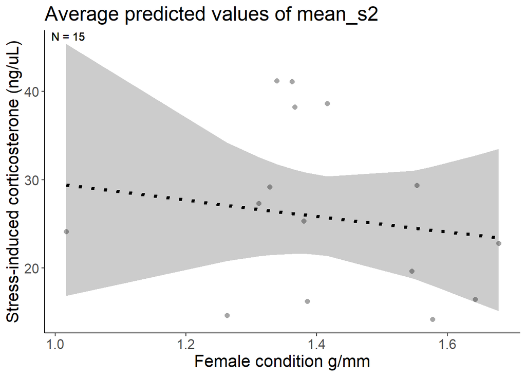

```r
mean_temp_TRES_q5h2 <- mean(data_TRES_q5h2 %>% pull(condition))
sd_temp_TRES_q5h2 <- sd(data_TRES_q5h2 %>% pull(condition))


temp_trans_TRES_q5h2 <- trans_new("temp_trans_TRES_q5h2",
                             transform = function(x){(x * sd_temp_TRES_q5h2) + mean_temp_TRES_q5h2},
                             inverse = function(x){x})

(figq5h2_TRES <- predict_response(m_TRES_q5h2,terms = c("condition_scaled"),margin = "empirical") %>%
    plot(line_size = 1.5,alpha = .2,show_data = TRUE,limit_range = TRUE) +
    aes(linetype = .data[["group"]]) +
    theme_classic() +
    # facet_wrap(~ group, ncol = 2) +
    xlab("Female condition g/mm") +
    ylab("Stress-induced corticosterone (ng/uL)") +
    scale_fill_viridis(discrete = TRUE) +
    scale_color_viridis(discrete = TRUE) +
    theme(text = element_text(size = 16)) +
    # labs(title =  "TRES baseline cort: max * LC interaction") +
    scale_x_continuous(trans = temp_trans_TRES_q5h2,
                       breaks = c((1-mean_temp_TRES_q5h2)/sd_temp_TRES_q5h2,
                                  (1.2-mean_temp_TRES_q5h2)/sd_temp_TRES_q5h2,
                                  (1.4-mean_temp_TRES_q5h2)/sd_temp_TRES_q5h2,
                                  (1.6-mean_temp_TRES_q5h2)/sd_temp_TRES_q5h2,
                                  (1.8-mean_temp_TRES_q5h2)/sd_temp_TRES_q5h2),
                       # breaks = c(20,30,40,50),
                       # labels = c("20","30","40","50"),
                       # limits = c((15-mean(g$meanmaxtempI,na.rm = TRUE))/sd(g$meanmaxtempI,na.rm = TRUE),
                       #            (55-mean(g$meanmaxtempI,na.rm = TRUE))/sd(g$meanmaxtempI,na.rm = TRUE))
                       # limits = c(18,5)
    ) +
    scale_linetype_manual(values = "dotted") +
    #ylim(-5,5) +
    geom_text(data = dat_text_TRES_q5h2, mapping = aes(x = -Inf, y = Inf,label = label),hjust = -.2, vjust = 1.2,inherit.aes = FALSE) +
    theme(legend.position = "none")
)
```

```r
ggsave("../figures/provisbymaxtempxhab_TRES_q5h2.png",plot =  figq5h2_TRES, width = 10, height = 6.6)
```